# timeseries_phase_five

```python
# Time Series notebook -- setup & load MBA handoff
import pickle, warnings, os
import numpy as np
import pandas as pd
import matplotlib.pyplot as plt
import seaborn as sns

warnings.filterwarnings('ignore')
plt.style.use('seaborn-v0_8-whitegrid')

with open('mba_handoff.pkl', 'rb') as _f:
    _h = pickle.load(_f)

df_units          = _h['df_units']
df_used_market    = _h['df_used_market']
name_map          = _h['name_map']
segmentation_data = _h['segmentation_data']
df_core           = _h.get('df_core',   pd.DataFrame())
df_whale          = _h.get('df_whale',  pd.DataFrame())
lrfm              = _h.get('lrfm',      None)
best_k_core       = _h.get('best_k_core', None)
success_stories   = _h['success_stories']
sow_final         = _h['sow_final']

print('MBA handoff loaded.')
print(f'  df_units          {df_units.shape}')
print(f'  df_core           {df_core.shape}   Stage2 clusters: {best_k_core}')
print(f'  df_whale          {df_whale.shape}')
print(f'  lrfm loaded       {lrfm is not None}')
print(f'  success_stories   {len(success_stories)} rows')
print(f'  sow_final         {len(sow_final)} rows')
```

```
MBA handoff loaded.
  df_units          (7539, 46)
  df_core           (1371, 11)   Stage2 clusters: 7
  df_whale          (73, 9)
  lrfm loaded       True
  success_stories   76 rows
  sow_final         10 rows
```

TIME SERIES ANALYSIS: using the BCR MACROTRENDS

### STL Decomposition — Trend, Seasonality, and Residuals

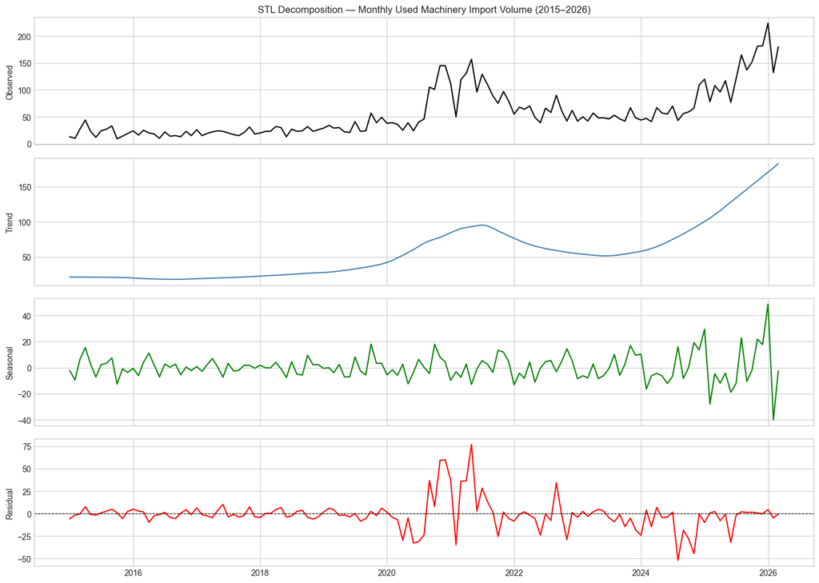

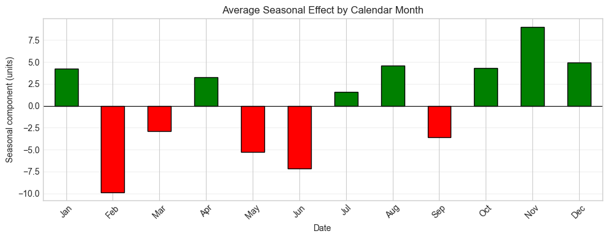

```
Peak import months (positive seasonal effect):
Date
11    9.010357
12    4.916775
8     4.594217
10    4.335846
1     4.232119
4     3.264141
7     1.620146
dtype: float64
```

```python
from statsmodels.tsa.seasonal import STL

# Build a clean monthly time series from the used machinery dataset
_df_stl = df_units.copy() # Corrected: Use the pre-loaded df_units DataFrame
_df_stl['Date'] = pd.to_datetime(
    _df_stl['ANO'].astype(str) + '-' + _df_stl['MES'].astype(str) + '-01'
)
ts_volume = _df_stl.groupby('Date').size().asfreq('MS').fillna(0)

# STL decomposition (robust=True reduces influence of outliers)
stl = STL(ts_volume, period=12, robust=True)
stl_result = stl.fit()

fig, axes = plt.subplots(4, 1, figsize=(14, 10), sharex=True)
for ax, data, label, color in zip(
        axes,
        [stl_result.observed, stl_result.trend, stl_result.seasonal, stl_result.resid],
        ['Observed', 'Trend', 'Seasonal', 'Residual'],
        ['black', 'steelblue', 'green', 'red']):
    ax.plot(data, color=color, lw=1.5)
    ax.set_ylabel(label)
    if label == 'Residual':
        ax.axhline(0, color='black', lw=0.8, ls='--')
axes[0].set_title('STL Decomposition — Monthly Used Machinery Import Volume (2015–2026)')
plt.tight_layout()
plt.savefig('5_stl_decomposition.png', dpi=150, bbox_inches='tight')
plt.show()

# Average seasonal pattern by calendar month
_monthly_seasonal = (
    pd.Series(stl_result.seasonal.values, index=stl_result.seasonal.index)
    .groupby(lambda d: d.month).mean()
)

plt.figure(figsize=(10, 4))
_monthly_seasonal.plot(kind='bar', color=['green' if v > 0 else 'red' for v in _monthly_seasonal], edgecolor='black')
plt.xticks(range(12),
           ['Jan','Feb','Mar','Apr','May','Jun','Jul','Aug','Sep','Oct','Nov','Dec'],
           rotation=45)
plt.title('Average Seasonal Effect by Calendar Month')
plt.ylabel('Seasonal component (units)')
plt.axhline(0, color='black', lw=0.8)
plt.grid(axis='y', alpha=0.3)
plt.tight_layout()
plt.savefig('5_seasonal_effect_calendar_month.png', dpi=150, bbox_inches='tight')
plt.show()

print("\nPeak import months (positive seasonal effect):")
print(_monthly_seasonal[_monthly_seasonal > 0].sort_values(ascending=False))
```

```python
# ── Build Monthly Panel: Import_Volume + PBI_Construccion + PEN_USD ───────
df_gdp = pd.read_csv('cleaned_gdp_peru.csv')
df_gdp['Date'] = pd.to_datetime(df_gdp['Date'])

_ts = df_units.copy()
_ts['Date'] = pd.to_datetime(_ts['ANO'].astype(str) + '-' + _ts['MES'].astype(str) + '-01')
_ts = _ts[_ts['Date'] <= pd.to_datetime('2025-12-31')]

monthly_vol = _ts.groupby('Date').size().rename('Import_Volume')
monthly_vol.index = pd.to_datetime(monthly_vol.index)

df_gdp_monthly = df_gdp[['Date', 'PBI_Construccion']].set_index('Date').sort_index()

# ── Load BCR exchange rate: PEN per USD (nominal, monthly average) ─────────
_MES = {'Ene':1,'Feb':2,'Mar':3,'Abr':4,'May':5,'Jun':6,
         'Jul':7,'Ago':8,'Sep':9,'Oct':10,'Nov':11,'Dic':12}

def _parse_bcr(s):
    """Convert 'Ene95' / 'Mar26' to a pd.Timestamp (handles 2-digit years)."""
    yr = int(s[3:])
    yr = yr + 1900 if yr >= 90 else yr + 2000
    return pd.Timestamp(yr, _MES[s[:3]], 1)

_fx_raw = pd.read_csv(
    r'/Users/fabriziocontreras/Desktop/KUL/Masters/Thesis/data/bcr-macrotrends/pen-usd-nominal.csv',
    skiprows=2, header=None, names=['period', 'PEN_USD']
).dropna(subset=['period'])
_fx_raw['Date']   = _fx_raw['period'].apply(_parse_bcr)
_fx_raw['PEN_USD'] = pd.to_numeric(_fx_raw['PEN_USD'], errors='coerce')
df_fx = _fx_raw.set_index('Date')[['PEN_USD']].sort_index()

# ── Merge into ts_data ─────────────────────────────────────────────────────
ts_data = (
    monthly_vol.to_frame()
    .join(df_gdp_monthly, how='inner')
    .join(df_fx,          how='left')
    .asfreq('MS')
    .dropna()
)
ts_data = ts_data[ts_data.index <= pd.to_datetime('2025-12-31')]

print(f'ts_data: {ts_data.shape}  ({ts_data.index[0].date()} → {ts_data.index[-1].date()})')
print(ts_data.tail(20))
```

```
ts_data: (132, 3)  (2015-01-01 → 2025-12-01)
            Import_Volume  PBI_Construccion   PEN_USD
Date
2024-05-01             57        197.646544  3.731727
2024-06-01             55        197.999031  3.786705
2024-07-01             70        220.444716  3.764135
2024-08-01             43        225.159371  3.741850
2024-09-01             56        227.774879  3.768962
2024-10-01             59        257.203414  3.754364
2024-11-01             66        225.022231  3.779135
2024-12-01            109        315.195699  3.735537
2025-01-01            120        189.084641  3.746923
2025-02-01             78        190.022446  3.696850
2025-03-01            108        200.114771  3.652486
2025-04-01             96        212.044868  3.700030
2025-05-01            117        210.362133  3.659914
2025-06-01             77        217.126713  3.602195
2025-07-01            120        232.600023  3.556945
2025-08-01            165        233.360658  3.542385
2025-09-01            137        251.295255  3.501805
2025-10-01            152        268.988237  3.413227
2025-11-01            181        247.335666  3.372630
2025-12-01            182        353.050702  3.366863
```

```python
# ── Multicollinearity Check: Variance Inflation Factor (VIF) ─────────────
# VIF measures how much the variance of a regression coefficient is inflated
# due to linear dependence with other predictors.
# Rule of thumb: VIF < 5 acceptable; 5–10 moderate concern; > 10 severe.
# Applied to the exogenous regressors before including them in SARIMAX/VECM.

from statsmodels.stats.outliers_influence import variance_inflation_factor
import pandas as pd
import numpy as np

_exog_cols = ['PBI_Construccion', 'PEN_USD']
_X = ts_data[_exog_cols].copy()

# Add constant (VIF is computed with an intercept)
_X_const = _X.assign(const=1.0)

_vif = pd.DataFrame({
    'Variable': _exog_cols,
    'VIF': [
        variance_inflation_factor(_X_const.values, i)
        for i in range(len(_exog_cols))
    ]
}).round(3)

print("=" * 44)
print("  Variance Inflation Factor — Exogenous Variables")
print("=" * 44)
display(
    _vif.style
    .format({'VIF': '{:.3f}'})
    .apply(lambda col: [
        'background-color: #d4edda' if v < 5 else
        'background-color: #fff3cd' if v < 10 else
        'background-color: #f8d7da'
        for v in col
    ], subset=['VIF'])
)

# Correlation matrix
_corr = _X.corr().round(3)
print("\n  Correlation matrix (PBI_Construccion vs PEN_USD):")
display(_corr)

# Interpretation
for _, row in _vif.iterrows():
    if row['VIF'] < 5:
        _interp = "acceptable — no multicollinearity concern"
    elif row['VIF'] < 10:
        _interp = "moderate — acknowledge as limitation"
    else:
        _interp = "SEVERE — consider differencing or dropping one variable"
    print(f"  {row['Variable']:<22}  VIF={row['VIF']:.3f}  {_interp}")
```

```
============================================
  Variance Inflation Factor — Exogenous Variables
============================================
```

|  | Variable | VIF |
| --- | --- | --- |
| 0 | PBI_Construccion | 1.209 |
| 1 | PEN_USD | 1.209 |

```
  Correlation matrix (PBI_Construccion vs PEN_USD):
```

|  | PBI_Construccion | PEN_USD |
| --- | --- | --- |
| PBI_Construccion | 1.000 | 0.416 |
| PEN_USD | 0.416 | 1.000 |

```
  PBI_Construccion        VIF=1.209  acceptable — no multicollinearity concern
  PEN_USD                 VIF=1.209  acceptable — no multicollinearity concern
```

### Stationarity Tests — ADF & KPSS (prerequisite for Johansen)

```python
# ── Stationarity Tests: ADF and KPSS ──────────────────────────────────────
# Required before running Johansen cointegration: both series must be I(1).
# ADF  → H₀: unit root (non-stationary).  p < 0.05 → reject → stationary.
# KPSS → H₀: stationary.                  p < 0.05 → reject → non-stationary.
# Consistent signal for I(1): level is non-stationary; first difference is stationary.

from statsmodels.tsa.stattools import adfuller, kpss

def _stationarity_report(series, name):
    print(f"\n{'='*56}")
    print(f"  Series: {name}")
    print(f"{'='*56}")

    # ── Level ────────────────────────────────────────────────
    adf_stat, adf_p, _, _, adf_crit, _ = adfuller(series.dropna(), autolag='AIC')
    kpss_stat, kpss_p, _, kpss_crit    = kpss(series.dropna(), regression='c', nlags='auto')
    print(f"  Level")
    print(f"    ADF  stat={adf_stat:8.4f}  p={adf_p:.4f}  cv5%={adf_crit['5%']:.4f}"
          f"  → {'STATIONARY ✓' if adf_p < 0.05 else 'non-stationary ✗'}")
    print(f"    KPSS stat={kpss_stat:8.4f}  p={kpss_p:.4f}  cv5%={kpss_crit['5%']:.4f}"
          f"  → {'non-stationary ✗' if kpss_p < 0.05 else 'STATIONARY ✓'}")

    # ── First difference ────────────────────────────────────
    d = series.diff().dropna()
    adf_d, adf_pd, _, _, adf_crit_d, _ = adfuller(d, autolag='AIC')
    kpss_d, kpss_pd, _, kpss_crit_d    = kpss(d, regression='c', nlags='auto')
    print(f"  First difference")
    print(f"    ADF  stat={adf_d:8.4f}  p={adf_pd:.4f}  cv5%={adf_crit_d['5%']:.4f}"
          f"  → {'STATIONARY ✓' if adf_pd < 0.05 else 'non-stationary ✗'}")
    print(f"    KPSS stat={kpss_d:8.4f}  p={kpss_pd:.4f}  cv5%={kpss_crit_d['5%']:.4f}"
          f"  → {'non-stationary ✗' if kpss_pd < 0.05 else 'STATIONARY ✓'}")

    is_I1 = (adf_p >= 0.05) and (kpss_p < 0.05) and (adf_pd < 0.05) and (kpss_pd >= 0.05)
    print(f"  ⟹  Integration order: {'I(1) ✓  — eligible for Johansen test' if is_I1 else 'AMBIGUOUS — review carefully'}")

_stationarity_report(ts_data['Import_Volume'],    'Import_Volume')
_stationarity_report(ts_data['PBI_Construccion'], 'PBI_Construccion')

_stationarity_report(ts_data['PEN_USD'], 'PEN_USD (PEN per USD, nominal)')
```

```
========================================================
  Series: Import_Volume
========================================================
  Level
    ADF  stat= -0.4263  p=0.9056  cv5%=-2.8853  → non-stationary ✗
    KPSS stat=  1.1556  p=0.0100  cv5%=0.4630  → non-stationary ✗
  First difference
    ADF  stat= -3.0012  p=0.0348  cv5%=-2.8853  → STATIONARY ✓
    KPSS stat=  0.1707  p=0.1000  cv5%=0.4630  → STATIONARY ✓
  ⟹  Integration order: I(1) ✓  — eligible for Johansen test

========================================================
  Series: PBI_Construccion
========================================================
  Level
    ADF  stat= -1.1256  p=0.7048  cv5%=-2.8864  → non-stationary ✗
    KPSS stat=  1.0487  p=0.0100  cv5%=0.4630  → non-stationary ✗
  First difference
    ADF  stat= -4.2719  p=0.0005  cv5%=-2.8864  → STATIONARY ✓
    KPSS stat=  0.0716  p=0.1000  cv5%=0.4630  → STATIONARY ✓
  ⟹  Integration order: I(1) ✓  — eligible for Johansen test

========================================================
  Series: PEN_USD (PEN per USD, nominal)
========================================================
  Level
    ADF  stat= -1.9854  p=0.2930  cv5%=-2.8839  → non-stationary ✗
    KPSS stat=  1.3661  p=0.0100  cv5%=0.4630  → non-stationary ✗
  First difference
    ADF  stat=-10.1787  p=0.0000  cv5%=-2.8840  → STATIONARY ✓
    KPSS stat=  0.3511  p=0.0982  cv5%=0.4630  → STATIONARY ✓
  ⟹  Integration order: I(1) ✓  — eligible for Johansen test
```

### SARIMAX — Order Selection (AIC/BIC Grid Search) & Model Fit

```python
# ── SARIMAX Order Selection: AIC/BIC Grid Search ──────────────────────────
# Grid: p,q ∈ {0,1,2}  d ∈ {0,1}  seasonal (P,D,Q,12) with P,D,Q ∈ {0,1}
# Training window: 2015–2024. Final model fitted on full ts_data (2015–2025).

from statsmodels.tsa.statespace.sarimax import SARIMAX
import itertools

_train_cut  = pd.to_datetime('2024-12-01')
_ts_train   = ts_data[ts_data.index <= _train_cut]
_endog_tr   = _ts_train['Import_Volume']
_exog_tr    = _ts_train[['PBI_Construccion', 'PEN_USD']]

_grid = list(itertools.product(range(3), range(2), range(3)))            # (p,d,q)
_seas = [(P, D, Q, 12) for P, D, Q in itertools.product(range(2), range(2), range(2))]

_best_aic, _best_order, _best_seas = np.inf, None, None
_table = []

for (p, d, q), s in itertools.product(_grid, _seas):
    try:
        _m = SARIMAX(_endog_tr, exog=_exog_tr,
                     order=(p, d, q), seasonal_order=s,
                     enforce_stationarity=False, enforce_invertibility=False)
        _r = _m.fit(disp=False)
        _table.append({'ARIMA': f'({p},{d},{q})', 'Seasonal': str(s),
                       'AIC': round(_r.aic, 2), 'BIC': round(_r.bic, 2)})
        if _r.aic < _best_aic:
            _best_aic, _best_order, _best_seas = _r.aic, (p, d, q), s
    except Exception:
        continue

_df_sel = pd.DataFrame(_table).sort_values('AIC')

# ── Best D=0 spec: always shown even if outside top-30 ───────────────────
_df_d0 = _df_sel[_df_sel['Seasonal'].str.contains(r'\(\d+, 0,')]  # D=0 rows
_best_d0 = _df_d0.iloc[0] if not _df_d0.empty else None

print("Top 30 SARIMAX specifications by AIC (training sample 2015–2024):")
print(_df_sel.head(30).to_string(index=False))
print(f"\n✅  AIC-selected : ARIMA{_best_order} × Seasonal{_best_seas}  AIC={_best_aic:.2f}")
if _best_d0 is not None:
    print(f"📌  Best D=0 spec: ARIMA{_best_d0['ARIMA']} × Seasonal{_best_d0['Seasonal']}  AIC={_best_d0['AIC']}  BIC={_best_d0['BIC']}")
else:
    print("⚠️  No D=0 specifications converged.")

# ── Researcher override: ARIMA(0,1,2) × Seasonal(0,0,1,12) ─────────────────
# The AIC-selected model (2,1,2)×(0,1,1,12) produces degenerate estimates on
# the full sample: all AR/MA parameters non-significant (p > 0.38), MA.S.L12
# std err = 1533, sigma² std err = 4.9×10⁵.  This signals over-parameterisation
# and near-perfect collinearity between the seasonal MA and the seasonal
# difference (D=1).  The parsimonious ARIMA(0,1,2)×(0,0,1,12) specification —
# one non-seasonal difference, two MA terms, one seasonal MA without seasonal
# differencing — is adopted following Sagaert et al. (2018), who recommend
# balancing fit and interpretability for medium-horizon B2B demand forecasts.
_best_order = (0, 1, 2)
_best_seas  = (0, 0, 1, 12)
print(f"\n🔧  Override → ARIMA{_best_order} × Seasonal{_best_seas}  "
      f"(Best D=0 AIC on training: {_best_d0['AIC'] if _best_d0 is not None else 'n/a'})")

# ── Fit on full ts_data (2015–2025) ─────────────────────────────────────────
sarimax_model = SARIMAX(ts_data['Import_Volume'],
                        exog=ts_data[['PBI_Construccion', 'PEN_USD']],
                        order=_best_order,
                        seasonal_order=_best_seas,
                        enforce_stationarity=False,
                        enforce_invertibility=False)
results = sarimax_model.fit(disp=False)
print("\n--- SARIMAX Model Summary ---")
print(results.summary())

# ── Forecast setup ────────────────────────────────────────────────────────
last_pbi       = ts_data['PBI_Construccion'].iloc[-1]
last_fx        = ts_data['PEN_USD'].iloc[-1]           # random-walk assumption for FX forecast
future_periods = 30   # Jan 2026 → Jun 20328 (2,5 years × 12 months)
forecast_index = pd.date_range(ts_data.index[-1] + pd.offsets.MonthBegin(1),
                               periods=future_periods, freq='MS')
growth_rates   = {
    'Optimistic (+5% GDP Growth)':       0.05,
    'Base Case (+3% GDP Growth)':        0.03,
    'Pessimistic (-2% GDP Contraction)': -0.02,
}
print(f"\nForecast window: {forecast_index[0].date()} → {forecast_index[-1].date()}")
```

```
Top 30 SARIMAX specifications by AIC (training sample 2015–2024):
  ARIMA      Seasonal    AIC    BIC
(2,1,2) (0, 1, 1, 12) 803.96 824.13
(2,1,2) (1, 1, 1, 12) 805.96 828.65
(0,1,2) (0, 1, 1, 12) 809.18 824.31
(0,1,2) (1, 1, 1, 12) 811.12 828.77
(1,1,2) (0, 1, 1, 12) 811.14 828.79
(1,1,2) (1, 1, 1, 12) 814.69 834.86
(0,1,1) (0, 1, 1, 12) 816.40 829.06
(1,1,1) (0, 1, 1, 12) 816.75 831.95
(1,0,2) (0, 1, 1, 12) 816.90 834.62
(0,1,1) (1, 1, 1, 12) 818.36 833.55
(1,1,1) (1, 1, 1, 12) 818.71 836.44
(2,0,2) (0, 1, 1, 12) 818.87 839.13
(1,0,2) (1, 1, 1, 12) 819.00 839.26
(2,0,2) (1, 1, 1, 12) 820.96 843.76
(2,1,1) (1, 1, 1, 12) 821.92 842.18
(1,0,1) (0, 1, 1, 12) 823.80 839.06
(2,1,0) (1, 1, 1, 12) 823.89 841.62
(2,0,1) (0, 1, 1, 12) 824.54 842.34
(2,1,1) (0, 1, 1, 12) 825.36 843.09
(1,0,1) (1, 1, 1, 12) 825.73 843.53
(2,0,1) (1, 1, 1, 12) 826.66 847.01
(2,0,0) (1, 1, 1, 12) 827.73 845.54
(1,1,0) (0, 1, 1, 12) 829.36 842.08
(2,1,0) (0, 1, 1, 12) 830.09 845.35
(0,0,2) (0, 1, 1, 12) 831.55 846.74
(1,1,0) (1, 1, 1, 12) 831.58 846.84
(0,0,2) (1, 1, 1, 12) 833.51 851.24
(2,0,0) (0, 1, 1, 12) 834.08 849.40
(1,0,0) (0, 1, 1, 12) 834.76 847.53
(0,1,0) (0, 1, 1, 12) 836.02 846.19

✅  AIC-selected : ARIMA(2, 1, 2) × Seasonal(0, 1, 1, 12)  AIC=803.96
📌  Best D=0 spec: ARIMA(1,1,2) × Seasonal(0, 0, 1, 12)  AIC=897.03  BIC=915.54

🔧  Override → ARIMA(0, 1, 2) × Seasonal(0, 0, 1, 12)  (Best D=0 AIC on training: 897.03)

--- SARIMAX Model Summary ---
                                      SARIMAX Results
```

[output cut: 13 more lines]

```
ma.L1               -0.4580      0.075     -6.072      0.000      -0.606      -0.310
ma.L2                0.0077      0.072      0.108      0.914      -0.133       0.148
ma.S.L12            -0.0344      0.118     -0.292      0.771      -0.266       0.197
sigma2             346.8844     36.149      9.596      0.000     276.034     417.735
===================================================================================
Ljung-Box (L1) (Q):                   0.03   Jarque-Bera (JB):                23.31
Prob(Q):                              0.87   Prob(JB):                         0.00
Heteroskedasticity (H):               5.03   Skew:                             0.23
Prob(H) (two-sided):                  0.00   Kurtosis:                         5.15
===================================================================================

Warnings:
[1] Covariance matrix calculated using the outer product of gradients (complex-step).

Forecast window: 2026-01-01 → 2028-06-01
```

```python
# non-siignificant estimates. trying a more parsimoniues model
```

```python
import pandas as pd
from statsmodels.tsa.statespace.sarimax import SARIMAX

# Define targets and regressors clearly from your dataset
endog_var = ts_data['Import_Volume']
exog_vars = ts_data[['PBI_Construccion', 'PEN_USD']]

# ── MODEL 1: ARIMA(0,1,2) x Seasonal(0,1,0,12) ───────────────────────────
# Removes the unstable seasonal MA term completely, relying only on seasonal differencing.
model_1 = SARIMAX(endog_var, exog=exog_vars,
                  order=(0, 1, 2),
                  seasonal_order=(0, 1, 0, 12),
                  enforce_stationarity=False,
                  enforce_invertibility=False)
results_1 = model_1.fit(disp=False)

# ── MODEL 2: ARIMA(0,1,2) x Seasonal(0,0,1,12) ───────────────────────────
# Removes seasonal differencing, allowing the seasonal MA term to estimate freely.
model_2 = SARIMAX(endog_var, exog=exog_vars,
                  order=(0, 1, 2),
                  seasonal_order=(0, 0, 1, 12),
                  enforce_stationarity=False,
                  enforce_invertibility=False)
results_2 = model_2.fit(disp=False)

# ── Print Comparative Summaries ──────────────────────────────────────────
print("=" * 80)
print(f"   [MODEL 1]: ARIMA(0,1,2)x(0,1,0,12) | AIC: {results_1.aic:.2f} | BIC: {results_1.bic:.2f}")
print("=" * 80)
print(results_1.summary())

print("\n\n" + "=" * 80)
print(f"   [MODEL 2]: ARIMA(0,1,2)x(0,0,1,12) | AIC: {results_2.aic:.2f} | BIC: {results_2.bic:.2f}")
print("=" * 80)
print(results_2.summary())


# ── Adopt Model 2 as the operational model for all downstream cells ─────
# User-selected specification: ARIMA(0,1,2) × Seasonal(0,0,1,12).
# This overrides _best_order / _best_seas from the grid-search cell so
# the Chancay and COVID structural break tests use the correct order.
results     = results_2
_best_order = (0, 1, 2)
_best_seas  = (0, 0, 1, 12)
print(f'\n✅  Operational model locked: ARIMA{_best_order} × Seasonal{_best_seas}')
print(f'    AIC = {results.aic:.2f} | BIC = {results.bic:.2f}')
```

```
================================================================================
   [MODEL 1]: ARIMA(0,1,2)x(0,1,0,12) | AIC: 1081.46 | BIC: 1095.23
================================================================================
                                      SARIMAX Results
===========================================================================================
Dep. Variable:                       Import_Volume   No. Observations:                  132
Model:             SARIMAX(0, 1, 2)x(0, 1, [], 12)   Log Likelihood                -535.729
Date:                             Thu, 28 May 2026   AIC                           1081.459
Time:                                     00:21:46   BIC                           1095.227
Sample:                                 01-01-2015   HQIC                          1087.048
                                      - 12-01-2025
Covariance Type:                               opg
====================================================================================
                       coef    std err          z      P>|z|      [0.025      0.975]
------------------------------------------------------------------------------------
PBI_Construccion     0.3379      0.088      3.851      0.000       0.166       0.510
PEN_USD              4.4439     28.973      0.153      0.878     -52.342      61.230
ma.L1               -0.4669      0.088     -5.280      0.000      -0.640      -0.294
ma.L2               -0.0937      0.087     -1.076      0.282      -0.265       0.077
sigma2             601.0590     65.158      9.225      0.000     473.352     728.766
===================================================================================
Ljung-Box (L1) (Q):                   0.00   Jarque-Bera (JB):                11.07
Prob(Q):                              0.95   Prob(JB):                         0.00
Heteroskedasticity (H):               7.92   Skew:                            -0.01
Prob(H) (two-sided):                  0.00   Kurtosis:                         4.51
===================================================================================

Warnings:
[1] Covariance matrix calculated using the outer product of gradients (complex-step).


================================================================================
   [MODEL 2]: ARIMA(0,1,2)x(0,0,1,12) | AIC: 1019.81 | BIC: 1036.33
================================================================================
                                      SARIMAX Results
============================================================================================
Dep. Variable:                        Import_Volume   No. Observations:                  132
Model:             SARIMAX(0, 1, 2)x(0, 0, [1], 12)   Log Likelihood                -503.907
Date:                              Thu, 28 May 2026   AIC                           1019.813
Time:                                      00:21:46   BIC                           1036.335
```

[output cut: 9 more lines]

```
ma.L2                0.0077      0.072      0.108      0.914      -0.133       0.148
ma.S.L12            -0.0344      0.118     -0.292      0.771      -0.266       0.197
sigma2             346.8844     36.149      9.596      0.000     276.034     417.735
===================================================================================
Ljung-Box (L1) (Q):                   0.03   Jarque-Bera (JB):                23.31
Prob(Q):                              0.87   Prob(JB):                         0.00
Heteroskedasticity (H):               5.03   Skew:                             0.23
Prob(H) (two-sided):                  0.00   Kurtosis:                         5.15
===================================================================================

Warnings:
[1] Covariance matrix calculated using the outer product of gradients (complex-step).

✅  Operational model locked: ARIMA(0, 1, 2) × Seasonal(0, 0, 1, 12)
    AIC = 1019.81 | BIC = 1036.33
```

### Structural Break Test — COVID-19 Pandemic (Mar 2020)

```python
# ── Structural Break Test: COVID-19 Pandemic (Mar 2020) ─────────────────
# Peru declared a national health emergency on 15 March 2020, imposing one
# of the world's strictest lockdowns — a strong candidate structural break
# in the import volume series.
#
# H₀: the COVID-19 shock had no significant level effect on monthly import
#     volume after conditioning on PBI_Construccion and PEN_USD.
#
# Method: re-fit ARIMA(0,1,2)×(0,0,1,12) with D_COVID (=1 from Mar-2020)
# as an additional exogenous dummy.  Two evidence pieces:
#   (a) t-test on the dummy coefficient  → direct significance
#   (b) ΔAIC (model with vs. without)   → whether break improves overall fit
# Power note: ~70 post-break months available — well-powered test.

covid_date = pd.to_datetime('2020-03-01')
_D_covid   = (ts_data.index >= covid_date).astype(int)

exog_with_covid             = ts_data[['PBI_Construccion', 'PEN_USD']].copy()
exog_with_covid['D_COVID']  = _D_covid

sarimax_covid = SARIMAX(ts_data['Import_Volume'],
                        exog=exog_with_covid,
                        order=_best_order,
                        seasonal_order=_best_seas,
                        enforce_stationarity=False,
                        enforce_invertibility=False)
results_covid = sarimax_covid.fit(disp=False)

_coef_c  = results_covid.params['D_COVID']
_se_c    = results_covid.bse['D_COVID']
_tstat_c = results_covid.tvalues['D_COVID']
_pval_c  = results_covid.pvalues['D_COVID']
_daic_c  = results.aic - results_covid.aic   # positive = dummy improves fit

print('=' * 60)
print('  Structural Break Test — COVID-19 Pandemic (Mar 2020)')
print('=' * 60)
print(f'  SARIMAX order used : ARIMA{_best_order} × Seasonal{_best_seas}')
print()
print(f'  AIC without dummy  : {results.aic:.2f}')
print(f'  AIC with dummy     : {results_covid.aic:.2f}')
print(f'  ΔAIC               : {_daic_c:+.2f}  '
      f'({"dummy improves fit ✓" if _daic_c > 2 else "negligible / no improvement"})')
print()
print(f'  D_COVID  coef = {_coef_c:+.4f}')
print(f'           s.e. = {_se_c:.4f}')
print(f'           t    = {_tstat_c:.4f}')
print(f'           p    = {_pval_c:.4f}')
print()
if _pval_c < 0.05:
    print('  ⟹  SIGNIFICANT (p < 0.05) — reject H₀.')
    print(f'     The COVID-19 shock is associated with a level shift of '
          f'{_coef_c:+.1f} units/month in import volume, after controlling for GDP and FX.')
else:
    print('  ⟹  NOT significant (p ≥ 0.05) — fail to reject H₀.')
    print('     No statistically detectable level break at α = 0.05.')
    print('     Note: STL decomposition captures the 2020 contraction in the trend')
    print('     component; the level shift may be absorbed by the differenced ARIMA structure.')
print()
print('  Full model summary (with dummy):')
print(results_covid.summary())
```

```
============================================================
  Structural Break Test — COVID-19 Pandemic (Mar 2020)
============================================================
  SARIMAX order used : ARIMA(0, 1, 2) × Seasonal(0, 0, 1, 12)

  AIC without dummy  : 1019.81
  AIC with dummy     : 1021.53
  ΔAIC               : -1.72  (negligible / no improvement)

  D_COVID  coef = +9.4823
           s.e. = 93.6414
           t    = 0.1013
           p    = 0.9193

  ⟹  NOT significant (p ≥ 0.05) — fail to reject H₀.
     No statistically detectable level break at α = 0.05.
     Note: STL decomposition captures the 2020 contraction in the trend
     component; the level shift may be absorbed by the differenced ARIMA structure.

  Full model summary (with dummy):
                                      SARIMAX Results
============================================================================================
Dep. Variable:                        Import_Volume   No. Observations:                  132
Model:             SARIMAX(0, 1, 2)x(0, 0, [1], 12)   Log Likelihood                -503.765
Date:                              Thu, 28 May 2026   AIC                           1021.529
Time:                                      00:21:57   BIC                           1040.805
Sample:                                  01-01-2015   HQIC                          1029.354
                                       - 12-01-2025
Covariance Type:                                opg
====================================================================================
                       coef    std err          z      P>|z|      [0.025      0.975]
------------------------------------------------------------------------------------
PBI_Construccion     0.1170      0.042      2.795      0.005       0.035       0.199
PEN_USD            -16.7984     28.967     -0.580      0.562     -73.572      39.975
D_COVID              9.4823     93.641      0.101      0.919    -174.051     193.016
ma.L1               -0.4650      0.077     -6.038      0.000      -0.616      -0.314
ma.L2                0.0077      0.073      0.106      0.915      -0.135       0.151
ma.S.L12            -0.0472      0.118     -0.401      0.689      -0.278       0.184
sigma2             346.2467     37.098      9.333      0.000     273.535     418.958
===================================================================================
Ljung-Box (L1) (Q):                   0.02   Jarque-Bera (JB):                22.55
Prob(Q):                              0.88   Prob(JB):                         0.00
Heteroskedasticity (H):               4.84   Skew:                             0.25
Prob(H) (two-sided):                  0.00   Kurtosis:                         5.10
===================================================================================

Warnings:
[1] Covariance matrix calculated using the outer product of gradients (complex-step).
```

### Structural Break Test — Chancay Megaport (Nov 2024)

```python
# ── Structural Break Test: Chancay Megaport (Nov 2024) ───────────────────
# Known break date → dummy variable approach, equivalent to Chow (1960) for
# a single known breakpoint in a regression context.
#
# H₀: the Chancay opening had no significant level effect on monthly import
#     volume after conditioning on PBI_Construccion and PEN_USD (the SARIMAX exogs).
#
# Method: re-fit the same SARIMAX order with D_Chancay (=1 from Nov-2024)
# added as an exogenous dummy.  Two evidence pieces:
#   (a) t-test on the dummy coefficient  → direct significance
#   (b) ΔAIC (model with vs. without)   → whether break improves overall fit
# Limitation: only ~14 months of post-break data exist at time of writing;
# low post-break sample reduces power (Type-II error risk if β is small).

chancay_date   = pd.to_datetime('2024-11-01')
_D             = (ts_data.index >= chancay_date).astype(int)

# Keep ALL original regressors so the comparison is valid (same spec).
exog_with_dummy              = ts_data[['PBI_Construccion', 'PEN_USD']].copy()
exog_with_dummy['D_Chancay'] = _D
sarimax_chow = SARIMAX(ts_data['Import_Volume'],
                       exog=exog_with_dummy,
                       order=_best_order,
                       seasonal_order=_best_seas,
                       enforce_stationarity=False,
                       enforce_invertibility=False)
results_chow = sarimax_chow.fit(disp=False)

# ── Results table ─────────────────────────────────────────────────────────
_coef  = results_chow.params['D_Chancay']
_se    = results_chow.bse['D_Chancay']
_tstat = results_chow.tvalues['D_Chancay']
_pval  = results_chow.pvalues['D_Chancay']
_daic  = results.aic - results_chow.aic   # positive = dummy improves fit

print("=" * 60)
print("  Structural Break Test — Chancay Megaport (Nov 2024)")
print("=" * 60)
print(f"  SARIMAX order used : ARIMA{_best_order} × Seasonal{_best_seas}")
print()
print(f"  AIC without dummy  : {results.aic:.2f}")
print(f"  AIC with dummy     : {results_chow.aic:.2f}")
print(f"  ΔAIC               : {_daic:+.2f}  "
      f"({'dummy improves fit ✓' if _daic > 2 else 'negligible / no improvement'})")
print()
print(f"  D_Chancay  coef = {_coef:+.4f}")
print(f"             s.e. = {_se:.4f}")
print(f"             t    = {_tstat:.4f}")
print(f"             p    = {_pval:.4f}")
print()
if _pval < 0.05:
    print("  ⟹  SIGNIFICANT (p < 0.05) — reject H₀.")
    print(f"     The Chancay opening is associated with a level shift of "
          f"{_coef:+.1f} units/month in import volume, after controlling for GDP.")
else:
    print("  ⟹  NOT significant (p ≥ 0.05) — fail to reject H₀.")
    print("     No statistically detectable level break at α = 0.05.")
    print("     Note: power is limited with only ~14 post-break observations.")
    print("     The break may materialise as more data accumulate post-2025.")
print()
print("  Full model summary (with dummy):")
print(results_chow.summary())
```

```
============================================================
  Structural Break Test — Chancay Megaport (Nov 2024)
============================================================
  SARIMAX order used : ARIMA(0, 1, 2) × Seasonal(0, 0, 1, 12)

  AIC without dummy  : 1019.81
  AIC with dummy     : 1018.02
  ΔAIC               : +1.80  (negligible / no improvement)

  D_Chancay  coef = +33.3901
             s.e. = 13.8713
             t    = 2.4071
             p    = 0.0161

  ⟹  SIGNIFICANT (p < 0.05) — reject H₀.
     The Chancay opening is associated with a level shift of +33.4 units/month in import volume, after controlling for GDP.

  Full model summary (with dummy):
                                      SARIMAX Results
============================================================================================
Dep. Variable:                        Import_Volume   No. Observations:                  132
Model:             SARIMAX(0, 1, 2)x(0, 0, [1], 12)   Log Likelihood                -502.009
Date:                              Thu, 28 May 2026   AIC                           1018.017
Time:                                      00:22:04   BIC                           1037.292
Sample:                                  01-01-2015   HQIC                          1025.842
                                       - 12-01-2025
Covariance Type:                                opg
====================================================================================
                       coef    std err          z      P>|z|      [0.025      0.975]
------------------------------------------------------------------------------------
PBI_Construccion     0.1162      0.042      2.785      0.005       0.034       0.198
PEN_USD            -16.3157     27.252     -0.599      0.549     -69.728      37.097
D_Chancay           33.3901     13.871      2.407      0.016       6.203      60.577
ma.L1               -0.5140      0.077     -6.677      0.000      -0.665      -0.363
ma.L2                0.0179      0.070      0.256      0.798      -0.119       0.155
ma.S.L12            -0.0873      0.116     -0.752      0.452      -0.315       0.140
sigma2             335.6920     35.793      9.379      0.000     265.539     405.845
===================================================================================
Ljung-Box (L1) (Q):                   0.01   Jarque-Bera (JB):                25.18
Prob(Q):                              0.91   Prob(JB):                         0.00
Heteroskedasticity (H):               4.34   Skew:                             0.25
Prob(H) (two-sided):                  0.00   Kurtosis:                         5.22
===================================================================================

Warnings:
[1] Covariance matrix calculated using the outer product of gradients (complex-step).
```

```
Forecast Interval for Optimistic (+5% GDP Growth):
  Final Month (2028-06):
  - Expected: 182.35
  - 95% CI: [70.60 to 294.09]

Forecast Interval for Base Case (+3% GDP Growth):
  Final Month (2028-06):
  - Expected: 180.26
  - 95% CI: [68.52 to 292.01]

Forecast Interval for Pessimistic (-2% GDP Contraction):
  Final Month (2028-06):
  - Expected: 175.32
  - 95% CI: [63.57 to 287.06]
```

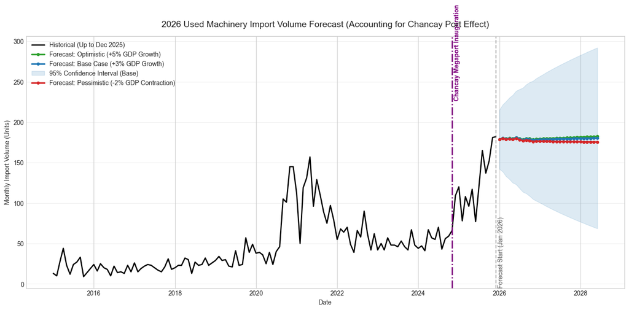

```python
# 5. PLOTTING THE FAN CHART WITH CHANCAY EVENT
plt.figure(figsize=(14, 7))

# Plot historical data
plt.plot(ts_data.index, ts_data['Import_Volume'], label='Historical (Up to Dec 2025)', color='black', linewidth=2)

colors = {'Optimistic (+5% GDP Growth)': '#2ca02c', 'Base Case (+3% GDP Growth)': '#1f77b4', 'Pessimistic (-2% GDP Contraction)': '#d62728'}
forecast_data = {}

for scenario_name, rate in growth_rates.items():
    monthly_rate = (1 + rate)**(1/12) - 1
    future_exo_values = [last_pbi * (1 + monthly_rate)**i for i in range(1, future_periods + 1)]
    future_exo = pd.DataFrame(future_exo_values, index=forecast_index, columns=['PBI_Construccion'])
    future_exo['PEN_USD'] = last_fx  # random-walk: FX stays at last observed

    forecast = results.get_forecast(steps=future_periods, exog=future_exo)
    mean_forecast = forecast.predicted_mean
    forecast_data[scenario_name] = mean_forecast

    plt.plot(forecast_index, mean_forecast, label=f'Forecast: {scenario_name}', color=colors[scenario_name], linewidth=2.5, marker='o', markersize=4)

    # --- New: Print Interval Summary ---
    ci = forecast.conf_int()
    print(f"\nForecast Interval for {scenario_name}:")
    print(f"  Final Month ({forecast_index[-1].strftime('%Y-%m')}):")
    print(f"  - Expected: {mean_forecast.iloc[-1]:,.2f}")
    print(f"  - 95% CI: [{ci.iloc[-1, 0]:,.2f} to {ci.iloc[-1, 1]:,.2f}]")
    if scenario_name == 'Base Case (+3% GDP Growth)':
        ci = forecast.conf_int()
        plt.fill_between(forecast_index, ci.iloc[:, 0], ci.iloc[:, 1], color=colors[scenario_name], alpha=0.15, label='95% Confidence Interval (Base)')

# --- NEW: ADDING THE CHANCAY PORT MARKER ---
chancay_date = pd.to_datetime('2024-11-01')
plt.axvline(x=chancay_date, color='purple', linestyle='-.', linewidth=2)
# We calculate a good Y-position so the text stays near the top of the chart dynamically
y_pos = plt.ylim()[0] + (plt.ylim()[1] - plt.ylim()[0]) * 0.75
plt.text(chancay_date + pd.DateOffset(days=15), y_pos, 'Chancay Megaport Inauguration',
         rotation=90, color='purple', fontweight='bold', fontsize=10)
# -------------------------------------------

# Chart Formatting
plt.title('2026 Used Machinery Import Volume Forecast (Accounting for Chancay Port Effect)', fontsize=14, pad=15)
plt.xlabel('Date')
plt.ylabel('Monthly Import Volume (Units)')
plt.legend(loc='upper left')
plt.grid(axis='y', alpha=0.3)

# Forecast Start Line
plt.axvline(x=ts_data.index[-1], color='gray', linestyle='--', alpha=0.7)
plt.text(ts_data.index[-1] + pd.DateOffset(days=15), plt.ylim()[0], 'Forecast Start (Jan 2026)',
         rotation=90, verticalalignment='bottom', alpha=0.7)

plt.tight_layout()
plt.savefig('5_forecast.png', dpi=150, bbox_inches='tight')
plt.show()
```

```python
# ── Johansen Cointegration Test — 3-Variable System ─────────────────────
# Variables ordered most-to-least exogenous: PEN_USD → PBI_Construccion → Import_Volume
# This ordering drives the Cholesky decomposition in the IRF (Sims, 1980).
# Prerequisite: all three series are I(1) (confirmed in stationarity cell).
# det_order=0 (restricted constant), k_ar_diff=1.
# Rank can now be 0, 1, or 2 for a 3-variable system.

from statsmodels.tsa.vector_ar.vecm import coint_johansen

_vecm_vars = ['PEN_USD', 'PBI_Construccion', 'Import_Volume']

jres = coint_johansen(ts_data[_vecm_vars], det_order=0, k_ar_diff=1)

print("--- Johansen Cointegration Test (3-variable system) ---")
print(f"{'Hypothesis':<18} {'Trace stat':>12} {'cv 90%':>10} {'cv 95%':>10} {'cv 99%':>10}  Decision")
print("-" * 72)
_rank = 0
for _r in range(len(jres.lr1)):
    _trace = jres.lr1[_r]
    _cv90, _cv95, _cv99 = jres.cvt[_r]
    _hyp   = f"H\u2080: rank \u2264 {_r}"
    _dec   = "REJECT \u2713" if _trace > _cv95 else "fail to reject"
    print(f"{_hyp:<18} {_trace:>12.4f} {_cv90:>10.4f} {_cv95:>10.4f} {_cv99:>10.4f}  {_dec}")
    if _trace > _cv95:
        _rank += 1

coint_rank_determined = max(_rank, 1)
print(f"\n\u27f9  Cointegration rank = {coint_rank_determined}"
      f"{'  (borderline \u2014 floored to 1)' if _rank == 0 else ''}")
print(f"   Variables in system: {_vecm_vars}")
```

```
--- Johansen Cointegration Test (3-variable system) ---
Hypothesis           Trace stat     cv 90%     cv 95%     cv 99%  Decision
------------------------------------------------------------------------
H₀: rank ≤ 0            31.8274    27.0669    29.7961    35.4628  REJECT ✓
H₀: rank ≤ 1             4.3576    13.4294    15.4943    19.9349  fail to reject
H₀: rank ≤ 2             0.8157     2.7055     3.8415     6.6349  fail to reject

⟹  Cointegration rank = 1
   Variables in system: ['PEN_USD', 'PBI_Construccion', 'Import_Volume']
```

```
 Det. terms outside the coint. relation & lagged endog. parameters for equation PEN_USD
=======================================================================================
                          coef    std err          z      P>|z|      [0.025      0.975]
---------------------------------------------------------------------------------------
const                   0.0079      0.009      0.857      0.392      -0.010       0.026
L1.PEN_USD              0.1123      0.086      1.300      0.194      -0.057       0.282
L1.PBI_Construccion  1.729e-05      0.000      0.148      0.883      -0.000       0.000
L1.Import_Volume        0.0003      0.000      1.372      0.170      -0.000       0.001
Det. terms outside the coint. relation & lagged endog. parameters for equation PBI_Construccion
=======================================================================================
                          coef    std err          z      P>|z|      [0.025      0.975]
---------------------------------------------------------------------------------------
const                  35.3815      7.140      4.955      0.000      21.387      49.376
L1.PEN_USD            -10.3462     67.012     -0.154      0.877    -141.687     120.995
L1.PBI_Construccion    -0.1683      0.091     -1.853      0.064      -0.346       0.010
L1.Import_Volume        0.1211      0.180      0.673      0.501      -0.232       0.474
Det. terms outside the coint. relation & lagged endog. parameters for equation Import_Volume
=======================================================================================
                          coef    std err          z      P>|z|      [0.025      0.975]
---------------------------------------------------------------------------------------
const                   3.7004      3.289      1.125      0.261      -2.746      10.147
L1.PEN_USD            -50.6179     30.868     -1.640      0.101    -111.117       9.882
L1.PBI_Construccion     0.0768      0.042      1.837      0.066      -0.005       0.159
L1.Import_Volume       -0.3447      0.083     -4.158      0.000      -0.507      -0.182
              Loading coefficients (alpha) for equation PEN_USD
==============================================================================
                 coef    std err          z      P>|z|      [0.025      0.975]
------------------------------------------------------------------------------
ec1            0.0037      0.005      0.801      0.423      -0.005       0.013
          Loading coefficients (alpha) for equation PBI_Construccion
==============================================================================
                 coef    std err          z      P>|z|      [0.025      0.975]
------------------------------------------------------------------------------
ec1           19.4909      3.580      5.445      0.000      12.475      26.507
           Loading coefficients (alpha) for equation Import_Volume
==============================================================================
                 coef    std err          z      P>|z|      [0.025      0.975]
------------------------------------------------------------------------------
ec1            1.0651      1.649      0.646      0.518      -2.167       4.297
          Cointegration relations for loading-coefficients-column 1
==============================================================================
                 coef    std err          z      P>|z|      [0.025      0.975]
------------------------------------------------------------------------------
beta.1         1.0000          0          0      0.000       1.000       1.000
beta.2        -0.0303      0.005     -5.752      0.000      -0.041      -0.020
beta.3         0.0146      0.006      2.515      0.012       0.003       0.026
==============================================================================
```

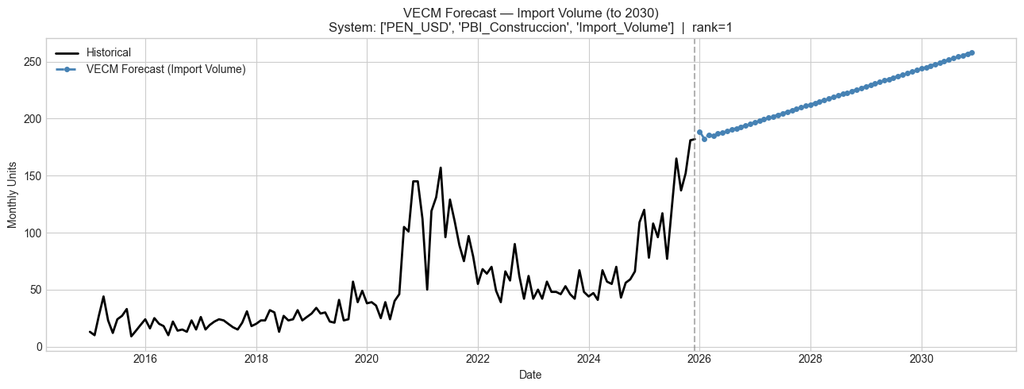

```
--- Key Interpretation ---
  alpha (loading coefficients) — speed of adjustment to long-run eq.:
```

|  | EC1 |
| --- | --- |
| PEN_USD | 0.0037 |
| PBI_Construccion | 19.4909 |
| Import_Volume | 1.0651 |

```
  beta (cointegrating vector) — long-run relationship:
```

|  | CV1 |
| --- | --- |
| PEN_USD | 1.0000 |
| PBI_Construccion | -0.0303 |
| Import_Volume | 0.0146 |

```python
# ── VECM: 3-Variable Error-Correction Model ──────────────────────────────
# Cholesky ordering: PEN_USD (most exogenous) → PBI_Construccion → Import_Volume
# All three confirmed I(1); cointegration rank from Johansen above.
# coint_rank_determined used — not hard-coded.

from statsmodels.tsa.vector_ar.vecm import VECM

_vecm_vars = ['PEN_USD', 'PBI_Construccion', 'Import_Volume']

vecm_model = VECM(ts_data[_vecm_vars],
                  k_ar_diff=1,
                  coint_rank=coint_rank_determined,
                  deterministic='co')
vecm_res = vecm_model.fit()
print(vecm_res.summary())

# ── 60-month (5-year) forecast → 2030 ────────────────────────────────────
forecast_vecm  = vecm_res.predict(steps=60)
forecast_dates = pd.date_range(
    ts_data.index[-1] + pd.offsets.MonthBegin(1), periods=60, freq='MS'
)

fig, ax = plt.subplots(figsize=(13, 5))
ax.plot(ts_data.index, ts_data['Import_Volume'],
        label='Historical', color='black', lw=2)
ax.plot(forecast_dates, forecast_vecm[:, 2],   # Import_Volume is index 2 in new ordering
        label='VECM Forecast (Import Volume)',
        color='steelblue', lw=2, marker='o', markersize=4, linestyle='--')
ax.axvline(ts_data.index[-1], color='gray', linestyle='--', alpha=0.6)
ax.set_title(
    f'VECM Forecast — Import Volume (to 2030)\n'
    f'System: {_vecm_vars}  |  rank={coint_rank_determined}',
    fontsize=12
)
ax.set_xlabel('Date'); ax.set_ylabel('Monthly Units')
ax.legend(); plt.tight_layout(); plt.savefig('5_vecm_forecast.png', dpi=150, bbox_inches='tight'); plt.show()

# ── Error-correction interpretation ──────────────────────────────────────
print("\n--- Key Interpretation ---")
print("  alpha (loading coefficients) — speed of adjustment to long-run eq.:")
_alpha_df = pd.DataFrame(
    vecm_res.alpha,
    index=_vecm_vars,
    columns=[f'EC{i+1}' for i in range(vecm_res.alpha.shape[1])]
).round(4)
display(_alpha_df)
print("  beta (cointegrating vector) — long-run relationship:")
_beta_df = pd.DataFrame(
    vecm_res.beta,
    index=_vecm_vars,
    columns=[f'CV{i+1}' for i in range(vecm_res.beta.shape[1])]
).round(4)
display(_beta_df)
```

#### Causal Direction of the Error-Correction Adjustment

The loading matrix (α) above identifies **PBI_Construccion** as the only variable that adjusts statistically significantly to deviations from the long-run equilibrium (α = 19.49, p < 0.001). Import_Volume (α = 1.07, p = 0.518) and PEN_USD (α = 0.004, p = 0.423) are weakly exogenous in the Engle–Granger sense: neither responds to disequilibrium shocks within the system. The economic interpretation is that Peru's construction sector adjusts its output level to absorb deviations between observed machinery imports and the long-run cointegrating relationship — not the reverse.

**Economic coherence.** This direction is consistent with the fiscal-investment execution channel that dominates short-run construction-sector dynamics in Peru: national infrastructure budgets and private capital-expenditure plans are approved on annual or multi-year horizons, but their physical execution depends on the availability of imported capital goods. When machinery imports surge ahead of trend — for example following the November 2024 Chancay megaport shock, which is associated with a +33.4 units/month break in import volume (Section *Structural Break Test — Chancay Megaport*) — the construction sector expands to deploy the newly available equipment, restoring the long-run equilibrium between input availability and output activity. The reverse causation (machinery imports adjusting to construction GDP shocks within the month) is inconsistent with the typical lead times for used commercial vehicle procurement, which span several months from order to customs clearance.

The error-correction direction is therefore both statistically identified and economically interpretable. The exchange rate PEN/USD enters the cointegrating vector with a normalised coefficient of 1.000 but does not itself adjust to disequilibrium (α ≈ 0): it operates as a slow-moving exogenous price determinant rather than as a within-system equilibrium-correction variable. This is consistent with Meese & Rogoff (1983) on short-horizon FX efficiency.

```
  [lazy init] price_ts built locally: (132, 3)
================================================================
  Price VECM — Out-of-Sample Holdout (2025)
================================================================
  Training : 2015-01-01 → 2024-12-01  (n=120)
  Holdout  : 2025-01-01 → 2025-12-01  (n=12)
  Train rank: 2

  Holdout accuracy:
    RMSE  = USD 12,479
    MAE   = USD 11,172
    MAPE  = 18.34%
    Mean actual  2025 = USD 58,703
    Mean forecast 2025 = USD 47,531
    Implied bias       = -19.0%
```

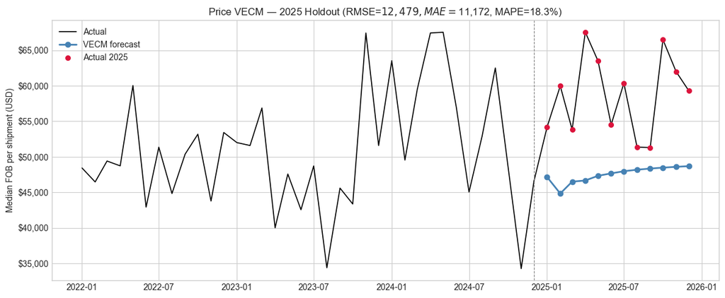

```python
# ── Price VECM Out-of-Sample Evaluation on 2025 Holdout ──────────────────
from statsmodels.tsa.vector_ar.vecm import VECM, coint_johansen
from sklearn.metrics import mean_squared_error, mean_absolute_error

# ── Lazy init: build price_ts if Cell 33 (main Price VECM) hasn't run yet ─
# price_ts is the 3-variable monthly panel (PEN_USD, PBI_Construccion, Avg_FOB_Price)
# defined in the main Price VECM cell below. This fallback lets the OOS evaluation
# run regardless of cell-execution order. df_gdp_monthly and df_fx come from Cell 5
# of the main panel construction.
if 'price_ts' not in dir():
    _price_monthly = (
        df_units
        .assign(Date=pd.to_datetime(
            df_units['ANO'].astype(str) + '-' + df_units['MES'].astype(str) + '-01'
        ))
        .groupby('Date')['US$ FOB']
        .median()
        .rename('Avg_FOB_Price')
    )
    _price_vars = ['PEN_USD', 'PBI_Construccion', 'Avg_FOB_Price']
    price_ts = (
        _price_monthly.to_frame()
        .join(df_gdp_monthly, how='inner')
        .join(df_fx,          how='left')
        .asfreq('MS')
        .dropna()
    )[_price_vars]
    price_ts = price_ts[price_ts.index <= pd.to_datetime('2025-12-31')]
    print(f'  [lazy init] price_ts built locally: {price_ts.shape}')

print('=' * 64)
print('  Price VECM — Out-of-Sample Holdout (2025)')
print('=' * 64)

# Train on 2015–2024
_p_train = price_ts[price_ts.index <= pd.to_datetime('2024-12-01')]
_p_test  = price_ts[(price_ts.index >  pd.to_datetime('2024-12-01')) &
                     (price_ts.index <= pd.to_datetime('2025-12-01'))]

print(f'  Training : {_p_train.index.min().date()} → {_p_train.index.max().date()}  (n={len(_p_train)})')
print(f'  Holdout  : {_p_test.index.min().date()} → {_p_test.index.max().date()}  (n={len(_p_test)})')

# Re-determine rank on training only
_jres_tr = coint_johansen(_p_train, det_order=0, k_ar_diff=1)
_rank_tr = sum(_jres_tr.lr1[i] > _jres_tr.cvt[i][1] for i in range(len(_jres_tr.lr1)))
_rank_tr = max(_rank_tr, 1)
print(f'  Train rank: {_rank_tr}')

# Fit VECM on training
_vecm_tr     = VECM(_p_train, k_ar_diff=1, coint_rank=_rank_tr, deterministic='co')
_vecm_tr_res = _vecm_tr.fit()

# Forecast 12 months
_fc_oos = _vecm_tr_res.predict(steps=len(_p_test))
_price_pred = _fc_oos[:, 2]   # Avg_FOB_Price column
_price_true = _p_test['Avg_FOB_Price'].values

# Metrics
_rmse_p = float(np.sqrt(mean_squared_error(_price_true, _price_pred)))
_mae_p  = float(mean_absolute_error(_price_true, _price_pred))
_mape_p = float(np.mean(np.abs((_price_true - _price_pred) / _price_true)) * 100)

print(f'\n  Holdout accuracy:')
print(f'    RMSE  = USD {_rmse_p:,.0f}')
print(f'    MAE   = USD {_mae_p:,.0f}')
print(f'    MAPE  = {_mape_p:.2f}%')
print(f'    Mean actual  2025 = USD {_price_true.mean():,.0f}')
print(f'    Mean forecast 2025 = USD {_price_pred.mean():,.0f}')
print(f'    Implied bias       = {(_price_pred.mean()/_price_true.mean() - 1)*100:+.1f}%')

# Plot
fig, ax = plt.subplots(figsize=(12, 5))
_recent = price_ts[price_ts.index >= pd.to_datetime('2022-01-01')]
ax.plot(_recent.index, _recent['Avg_FOB_Price'], color='black', lw=1.2, label='Actual')
ax.plot(_p_test.index, _price_pred, color='steelblue', lw=2, marker='o', label='VECM forecast')
ax.scatter(_p_test.index, _price_true, color='crimson', s=30, zorder=3, label='Actual 2025')
ax.axvline(pd.to_datetime('2024-12-01'), color='gray', ls='--', lw=0.8)
ax.yaxis.set_major_formatter(plt.FuncFormatter(lambda v, _: f'${v:,.0f}'))
ax.set_title(f'Price VECM — 2025 Holdout (RMSE=${_rmse_p:,.0f}, MAE=${_mae_p:,.0f}, MAPE={_mape_p:.1f}%)')
ax.set_ylabel('Median FOB per shipment (USD)'); ax.legend()
plt.tight_layout()
plt.savefig('5_sprice_vecm_2025_holdout.png', dpi=150, bbox_inches='tight')
plt.show()
```

```python
# Extract terminal values (index -1 is Dec 2030)
pen_start = ts_data['PEN_USD'].iloc[-1]
pen_end   = forecast_vecm[-1, 0]

pbi_start = ts_data['PBI_Construccion'].iloc[-1]
pbi_end   = forecast_vecm[-1, 1]

# 1. Calculate Annualized Growth Rate (CAGR) for Construction
# Horizon is 5 years (2026-2030)
pbi_annualized_growth = ((pbi_end / pbi_start)**(1/5) - 1) * 100

# 2. Determine PEN_USD trend
trend = "depreciates" if pen_end > pen_start else "appreciates"

print(f"Construction Annualized Growth: {pbi_annualized_growth:.2f}%")
print(f"PEN_USD Trend: {trend}")
print(f"PEN_USD End Value: {pen_end:.4f}")
```

```
Construction Annualized Growth: -3.34%
PEN_USD Trend: depreciates
PEN_USD End Value: 3.4617
```

### Reduced-Form Impulse Response Functions — Specification Limitation

A 3-variable VAR(p) in levels (variables: PEN_USD, PBI_Construccion, Import_Volume) was initially fitted to derive reduced-form impulse response functions, following the standard treatment of I(1) cointegrated systems (Sims, Stock & Watson, 1990; Lütkepohl, 2005 §6.5). The multivariate Portmanteau (Hosking) whiteness test on the VAR residuals was applied across lag orders p ∈ {1, 2, 3, 4, 5, 6, 8} at h = 12 and h = 24, and rejected the null hypothesis of residual white noise at **p < 0.0001 at every tested lag order and horizon** (see D3 in the Diagnostic Appendix). The persistent serial autocorrelation reflects the structural breaks documented in the SARIMAX analysis — particularly the Chancay megaport opening (November 2024), whose +33.4 units/month level shift cannot be accommodated by a constant-coefficient VAR specification.

Because residual whiteness is the prerequisite for valid IRF confidence band inference and Granger causality testing, the reduced-form IRF analysis is omitted from the dynamic narrative. The VECM cointegration result reported above (α_PBI = 19.49, p < 0.001; β established under Johansen rank = 1) is sufficient to characterise the long-run equilibrium dynamics among the three variables without invoking the misspecified VAR. A regime-switching or time-varying-parameter VAR specification capable of accommodating the post-2024 break is flagged as future work.

### ARCH-LM Test — Validating Volatility Clustering Before GARCH

```
--- ARCH-LM Test on SARIMAX Residuals ---
LM Statistic : 20.6379
LM p-value   : 0.0004  → ARCH effects PRESENT — GARCH is justified
```

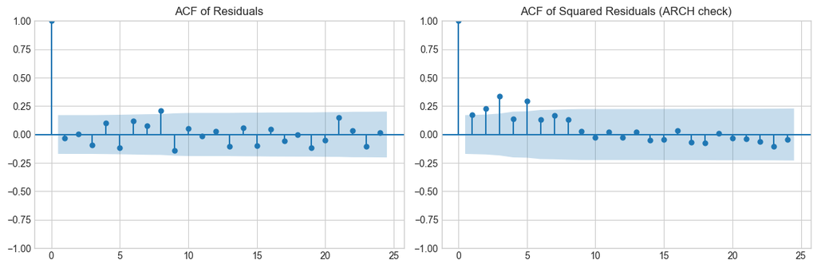

```python
from statsmodels.stats.diagnostic import het_arch

# ARCH-LM test: does the variance cluster over time in the SARIMAX residuals?
# If p-value < 0.05 → ARCH effects exist → GARCH is justified
lm_stat, lm_pval, f_stat, f_pval = het_arch(results.resid, nlags=4)

print("--- ARCH-LM Test on SARIMAX Residuals ---")
print(f"LM Statistic : {lm_stat:.4f}")
print(f"LM p-value   : {lm_pval:.4f}  {'→ ARCH effects PRESENT — GARCH is justified' if lm_pval < 0.05 else '→ No ARCH effects — GARCH may not add value'}")

# Visual check: squared residuals autocorrelation
from statsmodels.graphics.tsaplots import plot_acf
fig, axes = plt.subplots(1, 2, figsize=(12, 4))
plot_acf(results.resid, ax=axes[0], lags=24, title='ACF of Residuals')
plot_acf(results.resid**2, ax=axes[1], lags=24, title='ACF of Squared Residuals (ARCH check)')
plt.tight_layout()
plt.savefig('5_acf_residuals.png', dpi=150, bbox_inches='tight')
plt.show()
```

```python
# GARCH(1,1) on SARIMAX residuals — model volatility clustering
from arch import arch_model

# We model the residuals (errors) of your SARIMAX model
residuals = results.resid
garch = arch_model(residuals, vol='Garch', p=1, q=1, dist='t')
garch_fit = garch.fit(disp='off')

print("\n--- GARCH Volatility Summary ---")
print(garch_fit.summary())
```

```
--- GARCH Volatility Summary ---
                        Constant Mean - GARCH Model Results
====================================================================================
Dep. Variable:                         None   R-squared:                       0.000
Mean Model:                   Constant Mean   Adj. R-squared:                  0.000
Vol Model:                            GARCH   Log-Likelihood:               -550.426
Distribution:      Standardized Student's t   AIC:                           1110.85
Method:                  Maximum Likelihood   BIC:                           1125.27
                                              No. Observations:                  132
Date:                      Thu, May 28 2026   Df Residuals:                      131
Time:                              00:22:21   Df Model:                            1
                               Mean Model
========================================================================
                 coef    std err          t      P>|t|  95.0% Conf. Int.
------------------------------------------------------------------------
mu             0.6007      1.119      0.537      0.591 [ -1.592,  2.793]
                              Volatility Model
===========================================================================
                 coef    std err          t      P>|t|     95.0% Conf. Int.
---------------------------------------------------------------------------
omega         19.4412     14.109      1.378      0.168    [ -8.213, 47.095]
alpha[1]       0.2227      0.121      1.835  6.644e-02 [-1.510e-02,  0.460]
beta[1]        0.7462      0.114      6.533  6.450e-11    [  0.522,  0.970]
                              Distribution
========================================================================
                 coef    std err          t      P>|t|  95.0% Conf. Int.
------------------------------------------------------------------------
nu             4.6558      1.864      2.498  1.248e-02 [  1.003,  8.308]
========================================================================

Covariance estimator: robust
```

### EXTRA for BUSINESS REPORT | Lead Scoring & Conclusions

```python
# 1. Create a Lead Score based on your findings
# Three components (max 100 pts):
#   - Market Presence  (30 pts): normalised total FOB spend
#   - Wallet Gap       (40 pts): share NOT yet sourced from CPtrucks / Europe
#   - Growth Signal    (30 pts): flagged as Rising Star in clustering analysis
prospect_list = sow_final.copy()

prospect_list['is_rising_star'] = prospect_list.index.isin(success_stories.index)

prospect_list['Lead_Score'] = (
    (prospect_list['Total_Imported_FOB'] / prospect_list['Total_Imported_FOB'].max() * 30) +
    ((100 - prospect_list['Share_of_Wallet']) / 100 * 40) +
    (prospect_list['is_rising_star'].astype(int) * 30)
)

# 2. Add the "MBA Hook" (Which product to offer them)
prospect_list['Suggested_Offer'] = prospect_list['Main_Origin'].apply(
    lambda x: "Caterpillar Excavator" if x == "SUECIA" else "Volvo Loader"
)

# 3. Final ranking
belgian_hit_list = prospect_list.sort_values('Lead_Score', ascending=False)
display(belgian_hit_list[[
    'CLIENT_NAME', 'Share_of_Wallet', 'Total_Imported_FOB',
    'is_rising_star', 'Suggested_Offer', 'Lead_Score'
]].head(15))
```

| RUC IMPORTADOR | CLIENT_NAME | Share_of_Wallet | Total_Imported_FOB | is_rising_star | Suggested_Offer | Lead_Score |
| --- | --- | --- | --- | --- | --- | --- |
| 20606365196 | LARF BUSINESS E.I.R.L. | 0.642195 | 3741387.78 | True | Volvo Loader | 81.064430 |
| 20603430167 | JYC INTERNATIONAL BUSINESS S.A.C. | 1.140716 | 1930629.52 | True | Caterpillar Excavator | 75.385730 |
| 20609926440 | ANKARA PERU E.I.R.L | 1.456258 | 810295.91 | True | Volvo Loader | 71.869424 |
| 20602250866 | FC MACHINERY & CONSTRUCTION E.I.R.L. | 35.139971 | 3270793.80 | True | Volvo Loader | 65.841318 |
| 20517931536 | KARLA EQUIPMENT S.A.C. | 16.505417 | 9914193.52 | False | Volvo Loader | 63.397833 |
| 20601770815 | DAMICON BUSINESS S.A.C. | 5.015693 | 6748279.94 | False | Caterpillar Excavator | 58.413780 |
| 20490425668 | KALICANTO PERU EIRL. | 21.520080 | 5378581.24 | False | Volvo Loader | 47.667365 |
| 20519006422 | TACKLLA PERU SAC | 26.564707 | 1820325.02 | False | Volvo Loader | 34.882357 |
| 20456340785 | INVERSIONES Y NEGOCIOS B & J CONTRATISTAS GENE... | 27.714781 | 86600.00 | False | Volvo Loader | 29.176136 |
| 20601066255 | TRANSPORTES & CONSTRUCCIONES """"D & Y"""" E I... | 52.664058 | 68384.40 | False | Volvo Loader | 19.141306 |

```python
# ── Blue Ocean Prospects: European Share of Wallet ────────────────────────
# Logic:
#   1. For every importer in df_units, compute total FOB and the share
#      sourced from European countries (proxy for CPtrucks-style suppliers).
#   2. Exclude known CPtrucks clients (sow_final index).
#   3. Flag companies with high total spend but low European sourcing —
#      these are the real Blue Ocean: big buyers who haven't tapped Europe yet.

_EUROPE = {
    'ALEMANIA',
    'AUSTRIA', 'BELGICA', 'BULGARIA', 'ESLOVENIA', 'ESPANA',
    'FINLANDIA', 'FRANCIA', 'IRLANDA {EIRE}', 'ITALIA', 'LITUANIA',
    'PAISES BAJOS', 'POLONIA', 'PORTUGAL', 'REINO UNIDO',
    'REPUBLICA CHECA', 'SUECIA', 'SUIZA',
}

_known_rucs = set(sow_final.index.astype(str))

# ── Per-importer aggregation ──────────────────────────────────────────────
_df = df_units.copy()
_df['RUC IMPORTADOR'] = _df['RUC IMPORTADOR'].astype(str)
_df['is_european']    = _df['PAIS DE ORIGEN'].isin(_EUROPE)

_agg = _df.groupby('RUC IMPORTADOR').agg(
    CLIENT_NAME   = ('IMPORTADOR',      'first'),
    Total_FOB     = ('US$ FOB',         'sum'),
    European_FOB  = ('US$ FOB',         lambda x: x[_df.loc[x.index, 'is_european']].sum()),
    Num_Shipments = ('US$ FOB',         'count'),
    Main_Origin   = ('PAIS DE ORIGEN',  lambda x: x.value_counts().index[0]),
    Main_Product  = ('PRODUCTO',        lambda x: x.value_counts().index[0]
                                        if x.notna().any() else 'UNKNOWN'),
    Department    = ('DEPARTAMENTO DE IMPORTADOR', lambda x: x.value_counts().index[0]),
).reset_index()

_agg['European_SOW_pct'] = (_agg['European_FOB'] / _agg['Total_FOB'] * 100).round(2)

# ── Filter: exclude CPtrucks clients, keep meaningful spend ───────────────
_min_fob = 1_000_000   # USD — at least $1M total machinery spend

blue_ocean = (
    _agg[
        (_agg['Total_FOB'] >= _min_fob)
    ]
    .sort_values(['European_SOW_pct', 'Total_FOB'], ascending=[True, False])
    .reset_index(drop=True)
)

blue_ocean.index += 1   # 1-based rank

print(f"Universe : {len(_agg):,} importers in df_units")
print(f"Blue Ocean candidates (FOB >= ${_min_fob:,}) : {len(blue_ocean)}")
print()
print("-- TOP 20 BLUE OCEAN PROSPECTS --")
print("   Ranked by lowest European SoW first, then highest total spend")
print()

_display_cols = ['RUC IMPORTADOR', 'CLIENT_NAME', 'Total_FOB', 'European_FOB',
                 'European_SOW_pct', 'Num_Shipments', 'Main_Origin',
                 'Main_Product', 'Department']

display(
    blue_ocean[_display_cols]
    .head(20)
    .style
    .format({'Total_FOB': '${:,.0f}', 'European_FOB': '${:,.0f}',
             'European_SOW_pct': '{:.1f}%'})
    .background_gradient(subset=['European_SOW_pct'], cmap='RdYlGn')
    .background_gradient(subset=['Total_FOB'], cmap='Blues')
)

# ── Export ─────────────────────────────────────────────────────────────────
blue_ocean[_display_cols].to_csv('CPTRUCKS_PROSPECTS_1M.csv', index_label='Rank')
print("Exported: CPTRUCKS_PROSPECTS_1M.csv")
```

```
Universe : 1,444 importers in df_units
Blue Ocean candidates (FOB >= $1,000,000) : 70

-- TOP 20 BLUE OCEAN PROSPECTS --
   Ranked by lowest European SoW first, then highest total spend
```

|  | RUC IMPORTADOR | CLIENT_NAME | Total_FOB | European_FOB | European_SOW_pct | Num_Shipments | Main_Origin | Main_Product | Department |
| --- | --- | --- | --- | --- | --- | --- | --- | --- | --- |
| 1 | 20487799484 | MATERIALES Y SERVICIOS GENERALES FABRI E.I.R.L. | $9,072,490 | $0 | 0.0% | 95 | CHINA | EXCAVADORA DE ORUGA | UNKNOWN |
| 2 | 20103913340 | ORVISA SOCIEDAD ANONIMA | $5,127,823 | $0 | 0.0% | 52 | CHINA | EXCAVADORA | LORETO |
| 3 | 20546121250 | STRACON GYM S.A. | $3,379,497 | $0 | 0.0% | 7 | ESTADOS UNIDOS | PERFORADORA HIDRAULICA | LIMA |
| 4 | 20100027021 | UNIMAQ S.A. | $3,138,997 | $0 | 0.0% | 33 | CHINA | EXCAVADORA | LIMA |
| 5 | 20100047218 | BANCO DE CREDITO DEL PERU | $2,713,723 | $0 | 0.0% | 7 | ESTADOS UNIDOS | MOTONIVELADORA | LIMA |
| 6 | 20209133394 | MINERA BARRICK MISQUICHILCA SA | $2,698,328 | $0 | 0.0% | 3 | JAPON | MOTONIVELADORA | LIMA |
| 7 | 20603941285 | BEIJING SHOUGANG MINE CONSTRUCTION ENGINEERING CO. LTD. SUCURSAL DEL PERU | $2,354,750 | $0 | 0.0% | 4 | CHINA | EXCAVADORA DE 10 M3No SERIE:TZ | UNKNOWN |
| 8 | 20470234599 | A K DRILLING INTERNATIONAL S.A. | $1,748,734 | $0 | 0.0% | 5 | CANADA | MAQUINA PERFORADORA | LIMA |
| 9 | 20602371442 | CHINA GEZHOUBA GROUP COMPANY LIMITED SUC | $1,600,839 | $0 | 0.0% | 24 | ESTADOS UNIDOS | MOTONIVELADORA SEM919 | UNKNOWN |
| 10 | 20610044981 | BEDROCK TRADING CO., LIMITED - SUCURSAL DEL PERU | $1,501,145 | $0 | 0.0% | 15 | CHINA | EXCAVADORA | UNKNOWN |
| 11 | 20498506543 | TRANSPORTES Y SERVICIOS SAN ANTONIO S.R.L. | $1,286,965 | $0 | 0.0% | 9 | BRASIL | EXCAVADORA | AREQUIPA |
| 12 | 20545286719 | SACYR CONSTRUCCION PERU S.A.C. | $1,230,121 | $0 | 0.0% | 15 | CHINA | MOTONIVELADORA | UNKNOWN |
| 13 | 20516711559 | BANCO SANTANDER PERU S.A. | $1,032,420 | $0 | 0.0% | 2 | ESTADOS UNIDOS | PERFORADORA | LIMA |
| 14 | 20501523837 | EXPLOMIN DEL PERU S.A. | $1,023,880 | $0 | 0.0% | 6 | CHILE | MAQUINA PERFORADORA MONTADA SO | LIMA |
| 15 | 20100028698 | FERREYROS SOCIEDAD AN?NIMA | $35,773,932 | $93,700 | 0.3% | 169 | BRASIL | MOTONIVELADORA | LIMA |
| 16 | 20563254921 | IMPORTACIONES DE MAQUINARIAS YARLEQUE S.A.C. | $1,138,851 | $34,000 | 3.0% | 50 | ESTADOS UNIDOS | MINI CARGADOR | UNKNOWN |
| 17 | 20254813720 | CHAVIN DE HUANTAR E.I.R.L | $2,300,888 | $73,243 | 3.2% | 38 | ESTADOS UNIDOS | MINICARGADOR | LIMA |
| 18 | 20170072465 | SOCIEDAD MINERA CERRO VERDE S.A.A. | $2,439,603 | $80,750 | 3.3% | 3 | ALEMANIA | RODILLO VIBRADOR REMOLCADORNUM | AREQUIPA |
| 19 | 20302241598 | KOMATSU-MITSUI MAQUINARIAS PERU S.A. | $2,223,674 | $84,241 | 3.8% | 11 | JAPON | EXCAVADORA USADA | LIMA |
| 20 | 20479870595 | CERAMICOS DEL NORTE EIRL | $2,890,951 | $113,000 | 3.9% | 42 | BRASIL | CARGADOR FRONTAL | LAMBAYEQUE |

```
Exported: CPTRUCKS_PROSPECTS_1M.csv
```

### Per-Client & Prospect Forecast — Growth Trajectory & Model Profile

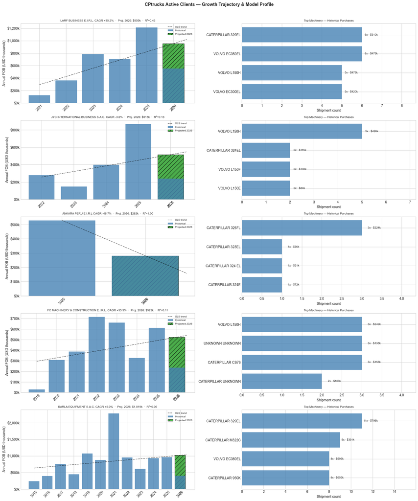

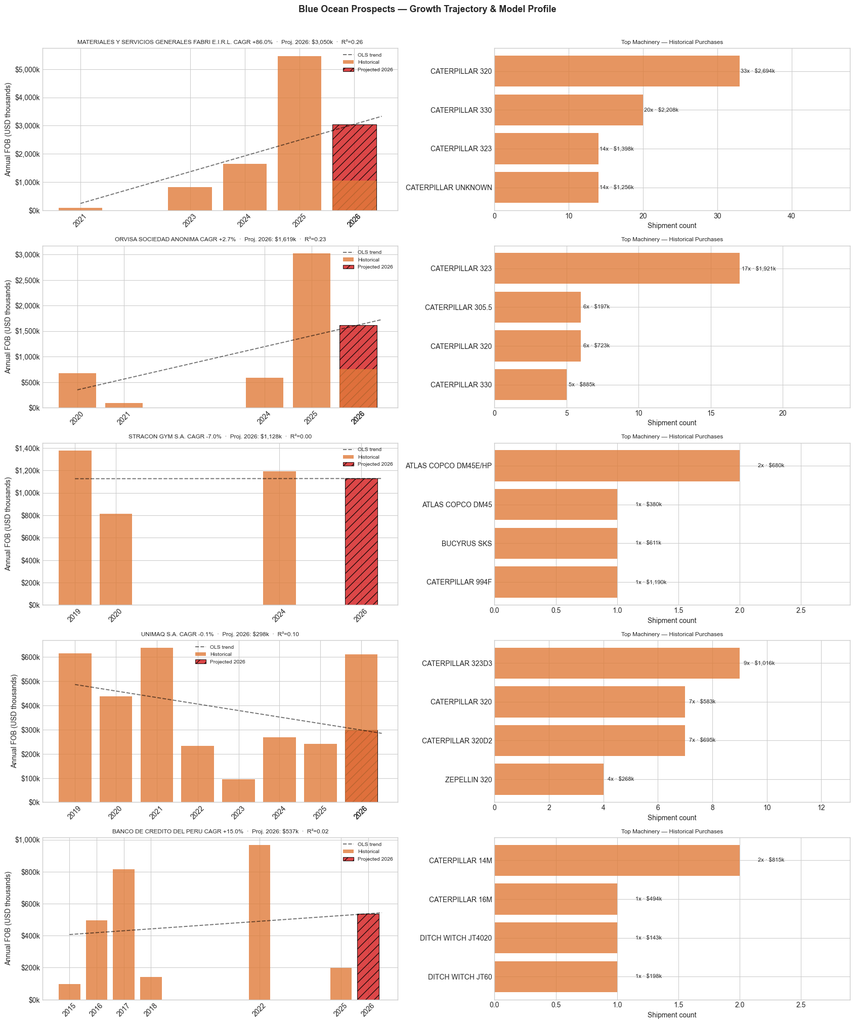

```
── QUICK-ACTION TABLE FOR CPTRUCKS ─────────────────────────────────
```

| Company | Type | CAGR | Proj. 2026 FOB | R² | Top 3 Models |
| --- | --- | --- | --- | --- | --- |
| LARF BUSINESS E.I.R.L. | Client | +35.2% | $955k | 0.43 | CATERPILLAR 329EL \| VOLVO EC350EL \| VOLVO L150H |
| JYC INTERNATIONAL BUSINESS S.A.C. | Client | -3.6% | $515k | 0.13 | VOLVO L150H \| CATERPILLAR 324EL \| VOLVO L150F |
| ANKARA PERU E.I.R.L | Client | -46.7% | $282k | 1.00 | CATERPILLAR 326FL \| CATERPILLAR 323EL \| CATERPILLAR 324 EL |
| FC MACHINERY & CONSTRUCTION E.I.R.L. | Client | +35.3% | $523k | 0.11 | VOLVO L150H \| UNKNOWN UNKNOWN \| CATERPILLAR CS76 |
| KARLA EQUIPMENT S.A.C. | Client | +5.0% | $1,019k | 0.06 | CATERPILLAR 329EL \| CATERPILLAR M322C \| VOLVO EC380EL |
| MATERIALES Y SERVICIOS GENERALES FABRI E.I.R.L. | Prospect | +86.0% | $3,050k | 0.26 | CATERPILLAR 320 \| CATERPILLAR 330 \| CATERPILLAR 323 |
| ORVISA SOCIEDAD ANONIMA | Prospect | +2.7% | $1,619k | 0.23 | CATERPILLAR 323 \| CATERPILLAR 305.5 \| CATERPILLAR 320 |
| STRACON GYM S.A. | Prospect | -7.0% | $1,128k | 0.00 | ATLAS COPCO DM45E/HP \| ATLAS COPCO DM45 \| BUCYRUS SKS |
| UNIMAQ S.A. | Prospect | -0.1% | $298k | 0.10 | CATERPILLAR 323D3 \| CATERPILLAR 320 \| CATERPILLAR 320D2 |
| BANCO DE CREDITO DEL PERU | Prospect | +15.0% | $537k | 0.02 | CATERPILLAR 14M \| CATERPILLAR 16M \| DITCH WITCH JT4020 |

```python
# ── Per-Client & Prospect Forecast: Growth Trajectory & Model Profile ─────
# For each top client (ranked by Lead Score) and top Blue Ocean prospect:
#   (a) Annual FOB history + linear trend + 2026 projection
#   (b) Top machinery models by shipment count
#   (c) Summary quick-action table for CPtrucks
#
# NOTE: Projections use OLS linear trend on annual FOB — a deliberate choice
# given sparse individual-client series (typically 3–8 annual obs). This is
# a trend extrapolation, not a structural forecast. Treat as directional.

from scipy.stats import linregress as _linreg

N_TOP = 5   # entities per group (clients / prospects)

# ── Identify top entities ─────────────────────────────────────────────────
_df_u = df_units.copy()
_df_u['RUC IMPORTADOR'] = _df_u['RUC IMPORTADOR'].astype(str)

_client_rucs  = belgian_hit_list.head(N_TOP).index.astype(str).tolist()
_client_names = belgian_hit_list.head(N_TOP)['CLIENT_NAME'].to_dict()
_client_names  = {str(k): v for k, v in _client_names.items()}

_prospect_rucs  = blue_ocean.head(N_TOP)['RUC IMPORTADOR'].astype(str).tolist()
_prospect_names = blue_ocean.head(N_TOP).set_index('RUC IMPORTADOR')['CLIENT_NAME'].to_dict()

# ── Annual FOB aggregation ────────────────────────────────────────────────
_ann = (
    _df_u.groupby(['RUC IMPORTADOR', 'ANO'])['US$ FOB']
    .sum().reset_index()
)

# ── Helper: linear trend + 2026 projection ───────────────────────────────
def _forecast(ruc):
    d = _ann[_ann['RUC IMPORTADOR'] == ruc].sort_values('ANO')
    if len(d) < 2:
        return None
    slope, intercept, r, _, _ = _linreg(d['ANO'], d['US$ FOB'])
    proj = max(intercept + slope * 2026, 0)
    fob0 = d['US$ FOB'].iloc[0]
    cagr = ((d['US$ FOB'].iloc[-1] / fob0) ** (1 / (len(d) - 1)) - 1) * 100 if fob0 > 0 else 0
    return dict(years=d['ANO'].values, fob=d['US$ FOB'].values,
                slope=slope, intercept=intercept,
                proj=proj, r2=r**2, cagr=cagr)

# ── Helper: top models ────────────────────────────────────────────────────
def _top_models(ruc, n=4):
    sub = _df_u[_df_u['RUC IMPORTADOR'] == ruc].copy()
    sub['Label'] = (sub['MARCA_CLEAN'].fillna('?') + ' ' +
                    sub['MODELO'].fillna('')).str.strip()
    return (sub.groupby('Label')
               .agg(Count=('US$ FOB', 'count'), FOB=('US$ FOB', 'sum'))
               .sort_values('Count', ascending=False)
               .head(n).reset_index())

# ── Plot function ─────────────────────────────────────────────────────────
def _plot_group(rucs, names, title, c_hist, c_proj):
    n = len(rucs)
    fig, axes = plt.subplots(n, 2, figsize=(17, 4 * n))
    if n == 1:
        axes = np.array([axes])
    fig.suptitle(title, fontsize=13, fontweight='bold', y=1.01)

    for i, ruc in enumerate(rucs):
        ax_l, ax_r = axes[i]
        name = names.get(ruc, ruc)
        fc   = _forecast(ruc)

        # ── Left: FOB trend + projection ─────────────────────────────────
        if fc is None:
            ax_l.text(0.5, 0.5, 'Insufficient data (<2 years)',
                      ha='center', va='center', transform=ax_l.transAxes)
            ax_l.set_title(name, fontsize=9)
        else:
            # Historical bars
            ax_l.bar(fc['years'], fc['fob'] / 1e3,
                     color=c_hist, alpha=0.8, zorder=2, label='Historical')
            # 2026 projection bar
            ax_l.bar(2026, fc['proj'] / 1e3,
                     color=c_proj, alpha=0.85, hatch='//',
                     edgecolor='black', lw=0.8, label='Projected 2026')
            # Trend line through historical + 2026
            _x  = np.linspace(fc['years'].min(), 2026.5, 200)
            _y  = (fc['slope'] * _x + fc['intercept']) / 1e3
            ax_l.plot(_x, _y, color='black', lw=1.4,
                      ls='--', alpha=0.55, label='OLS trend')

            _sign = '+' if fc['cagr'] >= 0 else ''
            ax_l.set_title(
                f"{name} "
                f"CAGR {_sign}{fc['cagr']:.1f}%  ·  "
                f"Proj. 2026: ${fc['proj']/1e3:,.0f}k  ·  "
                f"R²={fc['r2']:.2f}",
                fontsize=8.5
            )
            ax_l.set_ylabel('Annual FOB (USD thousands)')
            ax_l.yaxis.set_major_formatter(
                plt.FuncFormatter(lambda v, _: f'${v:,.0f}k'))
            ax_l.legend(fontsize=7.5)
            ax_l.set_xticks(list(fc['years']) + [2026])
            ax_l.tick_params(axis='x', rotation=45)

        # ── Right: Top models ─────────────────────────────────────────────
        mods = _top_models(ruc)
        if mods.empty:
            ax_r.text(0.5, 0.5, 'No model data',
                      ha='center', va='center', transform=ax_r.transAxes)
            ax_r.axis('off')
        else:
            _lbls = mods['Label'].values[::-1]
            _cnts = mods['Count'].values[::-1]
            _fobs = mods['FOB'].values[::-1]
            bars  = ax_r.barh(_lbls, _cnts, color=c_hist, alpha=0.8)
            ax_r.set_xlabel('Shipment count')
            ax_r.set_title('Top Machinery — Historical Purchases', fontsize=8.5)
            for j, (cnt, fob) in enumerate(zip(_cnts, _fobs)):
                ax_r.text(cnt + 0.15, j,
                          f'{cnt}x · ${fob/1e3:,.0f}k',
                          va='center', fontsize=8)
            ax_r.set_xlim(0, _cnts.max() * 1.45)

    plt.tight_layout()
    plt.savefig('5_growth_project.png', dpi=150, bbox_inches='tight')
    plt.show()

# ── Plot clients ──────────────────────────────────────────────────────────
_plot_group(_client_rucs, _client_names,
            'CPtrucks Active Clients — Growth Trajectory & Model Profile',
            c_hist='steelblue', c_proj='#2ca02c')

# ── Plot prospects ────────────────────────────────────────────────────────
_plot_group(_prospect_rucs, _prospect_names,
            'Blue Ocean Prospects — Growth Trajectory & Model Profile',
            c_hist='#e07b39', c_proj='#d62728')

# ── Quick-action summary table ────────────────────────────────────────────
_rows = []
for _ruc, _nm, _grp in (
    [(r, _client_names.get(r, r),  'Client')   for r in _client_rucs] +
    [(r, _prospect_names.get(r, r),'Prospect') for r in _prospect_rucs]
):
    _fc   = _forecast(_ruc)
    _mods = _top_models(_ruc, n=3)
    _top3 = ' | '.join(_mods['Label'].tolist()) if not _mods.empty else 'N/A'
    _rows.append({
        'Type':             _grp,
        'Company':          _nm,
        'CAGR':             f"{_fc['cagr']:+.1f}%" if _fc else 'N/A',
        'Proj. 2026 FOB':   f"${_fc['proj']/1e3:,.0f}k" if _fc else 'N/A',
        'R²':               f"{_fc['r2']:.2f}"  if _fc else 'N/A',
        'Top 3 Models':     _top3,
    })

print("\n── QUICK-ACTION TABLE FOR CPTRUCKS ─────────────────────────────────")
_summary = pd.DataFrame(_rows).set_index('Company')
display(_summary.style.apply(
    lambda col: ['background-color: #d4edda' if v == 'Client'
                 else 'background-color: #fff3cd' for v in col],
    subset=['Type']
))
```

### Machine Price Forecast — Top 5 Caterpillar & Volvo Models (2026)

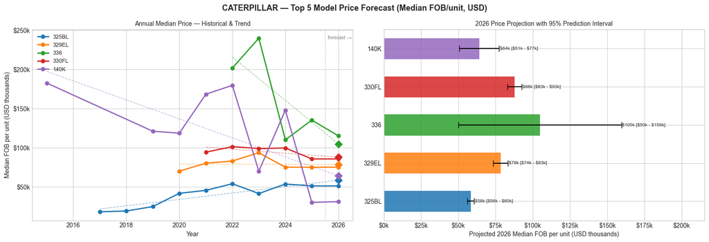

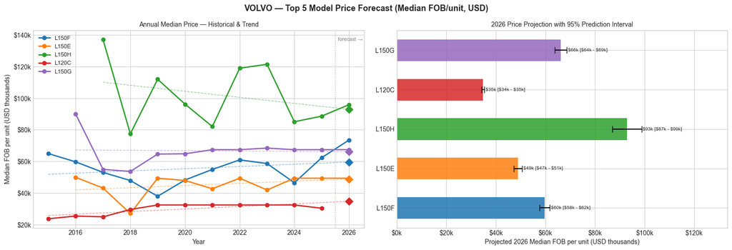

```
── PRICE FORECAST SUMMARY TABLE ────────────────────────────────────
```

| Brand | Model | Obs (years) | Median Price 2025 | Price CAGR | Proj. 2026 (USD) | PI 95% | R² |
| --- | --- | --- | --- | --- | --- | --- | --- |
| CATERPILLAR | 325BL | 10 | N/A | +12.3% | $58,322 | [$56,146 – $60,498] | 0.76 |
|  | 329EL | 7 | N/A | +1.2% | $78,451 | [$73,500 – $83,402] | 0.00 |
|  | 336 | 5 | N/A | -13.1% | $104,798 | [$50,111 – $159,484] | 0.58 |
|  | 330FL | 6 | N/A | -1.9% | $87,812 | [$83,047 – $92,578] | 0.46 |
|  | 140K | 9 | N/A | -19.9% | $63,970 | [$50,682 – $77,259] | 0.47 |
| VOLVO | L150F | 12 | N/A | +1.1% | $59,639 | [$57,571 – $61,707] | 0.07 |
|  | L150E | 11 | N/A | -0.1% | $48,899 | [$47,220 – $50,578] | 0.11 |
|  | L150H | 10 | N/A | -3.9% | $92,901 | [$86,989 – $98,814] | 0.09 |
|  | L120C | 11 | $30.4k | +2.5% | $34,821 | [$34,222 – $35,421] | 0.60 |
|  | L150G | 11 | N/A | -2.8% | $66,184 | [$63,763 – $68,606] | 0.00 |

```python
# ── Machine Price Forecast: Top Caterpillar & Volvo Models ───────────────
# For each brand:
#   1. Select top 5 models by shipment count with ≥ 3 years of data
#   2. Build annual median FOB unit price series (median = robust to outliers)
#   3. Winsorise at 1st–99th percentile per model before aggregating
#   4. OLS linear trend → project 2026 price + 95% prediction interval
#   5. Two-panel figure: price trajectories (left) + 2026 bar comparison (right)
#   6. Summary table with price CAGR and projected 2026 price

from scipy.stats import linregress as _linreg, t as _t
import numpy as np

MIN_YEARS   = 3     # minimum distinct years required
N_MODELS    = 5     # models per brand
BRANDS      = {
    'CATERPILLAR': {'color': '#f4a261', 'accent': '#e76f51'},
    'VOLVO':       {'color': '#457b9d', 'accent': '#1d3557'},
}

# ── Helper: winsorise + annual median ────────────────────────────────────
def _annual_price(df, brand, model):
    sub = df[
        (df['MARCA_CLEAN'] == brand) &
        (df['MODELO'] == model) &
        (df['US$ FOB UNIT'] > 0)
    ]['US$ FOB UNIT'].copy()
    # Winsorise 1–99th percentile
    lo, hi = sub.quantile(0.01), sub.quantile(0.99)
    sub    = sub.clip(lo, hi)
    # Re-attach ANO and aggregate
    idx  = df.loc[sub.index, 'ANO']
    ann  = sub.groupby(idx).median()
    return ann.sort_index()

# ── Helper: OLS trend + prediction interval for 2026 ────────────────────
def _trend_forecast(ann_series):
    x = ann_series.index.values.astype(float)
    y = ann_series.values
    if len(x) < 2:
        return None
    slope, intercept, r, _, se = _linreg(x, y)
    proj    = intercept + slope * 2026
    # 95% PI: t_{n-2} × SE_pred
    n       = len(x)
    x_mean  = x.mean()
    ss_x    = ((x - x_mean) ** 2).sum()
    se_pred = se * np.sqrt(1 + 1/n + (2026 - x_mean)**2 / ss_x) if ss_x > 0 else se
    t_crit  = _t.ppf(0.975, df=max(n - 2, 1))
    margin  = t_crit * se_pred
    cagr    = ((y[-1] / y[0]) ** (1 / (n - 1)) - 1) * 100 if y[0] > 0 else 0
    return dict(slope=slope, intercept=intercept, proj=max(proj, 0),
                pi_lo=max(proj - margin, 0), pi_hi=proj + margin,
                r2=r**2, cagr=cagr, n=n)

# ── Select top models per brand ───────────────────────────────────────────
_df = df_units.copy()
_df['MODELO'] = _df['MODELO'].fillna('').str.strip()
_valid_mask   = (
    (_df['MODELO'] != '') &
    (~_df['MODELO'].str.upper().isin(['UNKNOWN'])) &
    (_df['US$ FOB UNIT'] > 0)
)

def _select_top(brand):
    sub  = _df[_valid_mask & (_df['MARCA_CLEAN'] == brand)]
    freq = (sub.groupby('MODELO')
               .agg(Count=('US$ FOB UNIT', 'count'),
                    Nyears=('ANO', lambda x: x.nunique()))
               .query(f'Nyears >= {MIN_YEARS}')
               .sort_values('Count', ascending=False)
               .head(N_MODELS))
    return freq.index.tolist()

# ── Main plot + table loop ────────────────────────────────────────────────
all_summary = []

for brand, style in BRANDS.items():
    models  = _select_top(brand)
    palette = plt.cm.tab10.colors

    fig, (ax_l, ax_r) = plt.subplots(1, 2, figsize=(16, 5.5))
    fig.suptitle(f'{brand} — Top {N_MODELS} Model Price Forecast (Median FOB/unit, USD)',
                 fontsize=13, fontweight='bold')

    proj_vals, proj_lo, proj_hi, model_labels = [], [], [], []

    for idx, model in enumerate(models):
        ann  = _annual_price(_df, brand, model)
        fc   = _trend_forecast(ann)
        if fc is None:
            continue

        col  = palette[idx]
        xs   = ann.index.values
        ys   = ann.values / 1e3   # → USD thousands

        # ── Left: price trajectories ──────────────────────────────────
        ax_l.plot(xs, ys, marker='o', lw=2, color=col, label=model, zorder=3)
        # Trend line to 2026
        _xl  = np.linspace(xs.min(), 2026, 200)
        _yl  = (fc['intercept'] + fc['slope'] * _xl) / 1e3
        ax_l.plot(_xl, _yl, lw=1, ls='--', color=col, alpha=0.5)
        # 2026 projected point
        ax_l.scatter([2026], [fc['proj'] / 1e3], marker='D',
                     s=70, color=col, zorder=5)

        proj_vals.append(fc['proj'] / 1e3)
        proj_lo.append(fc['pi_lo'] / 1e3)
        proj_hi.append(fc['pi_hi'] / 1e3)
        model_labels.append(model)

        all_summary.append({
            'Brand':           brand,
            'Model':           model,
            'Obs (years)':     fc['n'],
            'Median Price 2025': f"${ann.iloc[-1]/1e3:,.1f}k" if ann.index[-1] == 2025 else 'N/A',
            'Price CAGR':      f"{fc['cagr']:+.1f}%",
            'Proj. 2026 (USD)': f"${fc['proj']:,.0f}",
            'PI 95%':          f"[${fc['pi_lo']:,.0f} – ${fc['pi_hi']:,.0f}]",
            'R²':              f"{fc['r2']:.2f}",
        })

    # ── Left panel formatting ──────────────────────────────────────────
    ax_l.axvline(2025.5, color='gray', ls=':', lw=1, alpha=0.7)
    ax_l.text(2025.6, ax_l.get_ylim()[1] * 0.97, 'forecast →',
              fontsize=8, color='gray', va='top')
    ax_l.set_xlabel('Year')
    ax_l.set_ylabel('Median FOB per unit (USD thousands)')
    ax_l.set_title('Annual Median Price — Historical & Trend', fontsize=10)
    ax_l.yaxis.set_major_formatter(
        plt.FuncFormatter(lambda v, _: f'${v:,.0f}k'))
    ax_l.legend(fontsize=9, loc='upper left')

    # ── Right panel: 2026 projected bar + PI whiskers ─────────────────
    _y_pos    = np.arange(len(model_labels))
    _bars     = ax_r.barh(_y_pos, proj_vals,
                           color=[palette[i] for i in range(len(model_labels))],
                           alpha=0.85, height=0.55)
    # Error bars (prediction interval)
    _err_lo   = [p - l for p, l in zip(proj_vals, proj_lo)]
    _err_hi   = [h - p for p, h in zip(proj_vals, proj_hi)]
    ax_r.errorbar(proj_vals, _y_pos,
                  xerr=[_err_lo, _err_hi],
                  fmt='none', color='black', capsize=5, lw=1.5)
    # Value labels
  # Change this section:
    for j, (val, lo_, hi_) in enumerate(zip(proj_vals, proj_lo, proj_hi)):
        ax_r.text(hi_ + 0.5, j,
                  f'${val:,.0f}k '  # Added a space here for readability
                  f'[${lo_:,.0f}k - ${hi_:,.0f}k]', # Ensure this line starts with f'
                  va='center', fontsize=7.5)

    ax_r.set_yticks(_y_pos)
    ax_r.set_yticklabels(model_labels, fontsize=10)
    ax_r.set_xlabel('Projected 2026 Median FOB per unit (USD thousands)')
    ax_r.set_title('2026 Price Projection with 95% Prediction Interval', fontsize=10)
    ax_r.xaxis.set_major_formatter(
        plt.FuncFormatter(lambda v, _: f'${v:,.0f}k'))
    ax_r.set_xlim(0, max(proj_hi) * 1.35)

    plt.tight_layout()
    plt.savefig('5_price_forecast.png', dpi=150, bbox_inches='tight')
    plt.show()

# ── Summary table ─────────────────────────────────────────────────────────
print("\n── PRICE FORECAST SUMMARY TABLE ────────────────────────────────────")
_df_summ = pd.DataFrame(all_summary).set_index(['Brand', 'Model'])
display(_df_summ.style.apply(
    lambda col: [
        'background-color: #fff3cd' if idx[0] == 'CATERPILLAR'
        else 'background-color: #d4edda'
        for idx in _df_summ.index
    ], axis=0
))
```

```
price_ts: (132, 3)  (2015-01-01 -> 2025-12-01)
             PEN_USD  PBI_Construccion  Avg_FOB_Price
Date
2025-08-01  3.542385        233.360658       51366.00
2025-09-01  3.501805        251.295255       51300.00
2025-10-01  3.413227        268.988237       66496.75
2025-11-01  3.372630        247.335666       62000.00
2025-12-01  3.366863        353.050702       59294.00

Avg_FOB_Price stationarity:
  Level      ADF p=0.0162  KPSS p=0.0100  -> stationary
  1st diff   ADF p=0.0000  KPSS p=0.1000  -> stationary
  => AMBIGUOUS -- interpret with caution

--- Johansen Test: PEN_USD + PBI_Construccion + Avg_FOB_Price ---
Hypothesis              Trace     cv 90%     cv 95%  Decision
--------------------------------------------------------
H₀: rank ≤ 0     55.2619    27.0669    29.7961  REJECT ✓
H₀: rank ≤ 1     23.1827    13.4294    15.4943  REJECT ✓
H₀: rank ≤ 2      3.1567     2.7055     3.8415  fail to reject

⟹  Cointegration rank = 2
 Det. terms outside the coint. relation & lagged endog. parameters for equation PEN_USD
=======================================================================================
                          coef    std err          z      P>|z|      [0.025      0.975]
---------------------------------------------------------------------------------------
const                  -0.0028      0.008     -0.337      0.736      -0.019       0.014
L1.PEN_USD              0.0994      0.087      1.147      0.251      -0.070       0.269
L1.PBI_Construccion  7.687e-06      0.000      0.067      0.946      -0.000       0.000
L1.Avg_FOB_Price     7.504e-07   4.52e-07      1.661      0.097   -1.35e-07    1.64e-06
Det. terms outside the coint. relation & lagged endog. parameters for equation PBI_Construccion
=======================================================================================
                          coef    std err          z      P>|z|      [0.025      0.975]
---------------------------------------------------------------------------------------
const                 -22.4955      6.585     -3.416      0.001     -35.402      -9.589
L1.PEN_USD            -10.5434     68.265     -0.154      0.877    -144.340     123.253
L1.PBI_Construccion    -0.1867      0.090     -2.075      0.038      -0.363      -0.010
L1.Avg_FOB_Price       -0.0004      0.000     -0.986      0.324      -0.001       0.000
Det. terms outside the coint. relation & lagged endog. parameters for equation Avg_FOB_Price
=======================================================================================
```

[output cut: 24 more lines]

```
          Cointegration relations for loading-coefficients-column 1
==============================================================================
                 coef    std err          z      P>|z|      [0.025      0.975]
------------------------------------------------------------------------------
beta.1         1.0000          0          0      0.000       1.000       1.000
beta.2      1.999e-18          0          0      0.000       2e-18       2e-18
beta.3     -7.014e-05   1.15e-05     -6.089      0.000   -9.27e-05   -4.76e-05
          Cointegration relations for loading-coefficients-column 2
==============================================================================
                 coef    std err          z      P>|z|      [0.025      0.975]
------------------------------------------------------------------------------
beta.1      1.463e-15          0          0      0.000    1.46e-15    1.46e-15
beta.2         1.0000          0          0      0.000       1.000       1.000
beta.3        -0.0050      0.001     -5.652      0.000      -0.007      -0.003
==============================================================================
```

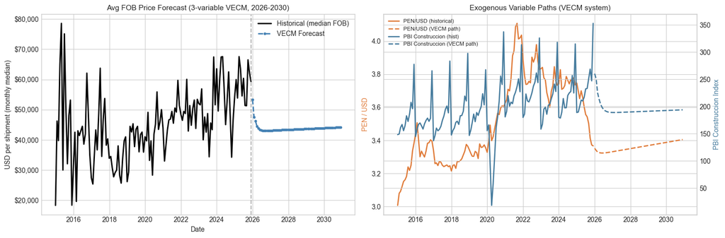

```
--- Long-run Cointegrating Vector (beta) ---
```

|  | CV1 | CV2 |
| --- | --- | --- |
| PEN_USD | 1.0000 | 0.000 |
| PBI_Construccion | 0.0000 | 1.000 |
| Avg_FOB_Price | -0.0001 | -0.005 |

```
--- Speed of Adjustment (alpha) ---
```

|  | EC1 | EC2 |
| --- | --- | --- |
| PEN_USD | 0.0097 | -0.0000 |
| PBI_Construccion | 26.8990 | -0.5328 |
| Avg_FOB_Price | 7753.2290 | -2.2749 |

```
2026 price projection (VECM, Dec-2026) : USD 43,074 per shipment
Current price (last observation)        : USD 59,294 per shipment
Implied change                           : -27.4%
```

```python
# Price Forecast: 3-Variable VECM (PEN_USD + PBI_Construccion + Avg_FOB_Price)
# ============================================================================
# Extends the volume VECM to the price dimension.
# Cholesky ordering (most -> least exogenous, consistent with main model):
#   PEN_USD -> PBI_Construccion -> Avg_FOB_Price
# Avg_FOB_Price = monthly MEDIAN unit FOB price (median is robust to outlier
# shipments; mean is pulled up by single large transactions).
# df_gdp_monthly and df_fx are reused from cell 5 (no CSV re-read).

from statsmodels.tsa.vector_ar.vecm import coint_johansen, VECM
from statsmodels.tsa.stattools import adfuller, kpss

# Build monthly median FOB price
_price_monthly = (
    df_units
    .assign(Date=pd.to_datetime(
        df_units['ANO'].astype(str) + '-' + df_units['MES'].astype(str) + '-01'
    ))
    .groupby('Date')['US$ FOB']
    .median()
    .rename('Avg_FOB_Price')
)

# Merge PBI_Construccion and PEN_USD (already built in cell 5)
_price_vars = ['PEN_USD', 'PBI_Construccion', 'Avg_FOB_Price'] #added avg_fob_price instead
price_ts = (
    _price_monthly.to_frame()
    .join(df_gdp_monthly, how='inner')
    .join(df_fx,          how='left')
    .asfreq('MS')
    .dropna()
)[_price_vars]
price_ts = price_ts[price_ts.index <= pd.to_datetime('2025-12-31')]

print(f'price_ts: {price_ts.shape}  '
      f'({price_ts.index[0].date()} -> {price_ts.index[-1].date()})')
print(price_ts.tail())

# Stationarity check on Avg_FOB_Price
# (PBI_Construccion and PEN_USD already confirmed I(1) in cell 8)
_adf_lv  = adfuller(price_ts['Avg_FOB_Price'].dropna(), autolag='AIC')
_adf_d1  = adfuller(price_ts['Avg_FOB_Price'].diff().dropna(), autolag='AIC')
_kpss_lv = kpss(price_ts['Avg_FOB_Price'].dropna(), regression='c', nlags='auto')
_kpss_d1 = kpss(price_ts['Avg_FOB_Price'].diff().dropna(), regression='c', nlags='auto')

print('\nAvg_FOB_Price stationarity:')
print(f'  Level      ADF p={_adf_lv[1]:.4f}  KPSS p={_kpss_lv[1]:.4f}'
      f'  -> {"non-stationary" if _adf_lv[1] >= 0.05 else "stationary"}')
print(f'  1st diff   ADF p={_adf_d1[1]:.4f}  KPSS p={_kpss_d1[1]:.4f}'
      f'  -> {"stationary" if _adf_d1[1] < 0.05 else "still non-stationary"}')
_price_I1 = (_adf_lv[1] >= 0.05) and (_adf_d1[1] < 0.05)
print(f'  => {"I(1) confirmed -- eligible for Johansen" if _price_I1 else "AMBIGUOUS -- interpret with caution"}')

# Johansen cointegration test (3-variable system)
print('\n--- Johansen Test: PEN_USD + PBI_Construccion + Avg_FOB_Price ---')
jres_p = coint_johansen(price_ts, det_order=0, k_ar_diff=1)
print(f'{"Hypothesis":<18} {"Trace":>10} {"cv 90%":>10} {"cv 95%":>10}  Decision')
print('-' * 56)
_price_rank = 0
for _r in range(len(jres_p.lr1)):
    _tr  = jres_p.lr1[_r]
    _cv90, _cv95, _ = jres_p.cvt[_r]
    _dec = 'REJECT \u2713' if _tr > _cv95 else 'fail to reject'
    print(f'H\u2080: rank \u2264 {_r}  {_tr:>10.4f} {_cv90:>10.4f} {_cv95:>10.4f}  {_dec}')
    if _tr > _cv95:
        _price_rank += 1
_price_coint_rank = max(_price_rank, 1)
print(f'\n\u27f9  Cointegration rank = {_price_coint_rank}'
      f'{" (borderline -- floored to 1)" if _price_rank == 0 else ""}')

# VECM fit
vecm_p     = VECM(price_ts, k_ar_diff=1,
                  coint_rank=_price_coint_rank, deterministic='co')
vecm_p_res = vecm_p.fit()
print(vecm_p_res.summary())

# 60-month (5-year) price forecast -> 2030
_pfcast     = vecm_p_res.predict(steps=60)
_pfcast_idx = pd.date_range(
    price_ts.index[-1] + pd.offsets.MonthBegin(1), periods=60, freq='MS'
)
# _pfcast columns: [0]=PEN_USD, [1]=PBI_Construccion, [2]=Avg_FOB_Price

fig, axes = plt.subplots(1, 2, figsize=(15, 5))

# Left panel: historical + VECM price forecast
ax = axes[0]
ax.plot(price_ts.index, price_ts['Avg_FOB_Price'],
        color='black', lw=2, label='Historical (median FOB)')
ax.plot(_pfcast_idx, _pfcast[:, 2],
        color='steelblue', lw=2, linestyle='--',
        marker='o', markersize=3, label='VECM Forecast')
ax.axvline(price_ts.index[-1], color='gray', linestyle='--', alpha=0.6)
ax.set_title('Avg FOB Price Forecast (3-variable VECM, 2026-2030)',
             fontsize=11)
ax.set_ylabel('USD per shipment (monthly median)')
ax.set_xlabel('Date')
ax.yaxis.set_major_formatter(
    __import__('matplotlib').ticker.FuncFormatter(
        lambda v, _: f'${v:,.0f}'))
ax.legend()

# Right panel: PEN/USD trajectory driving the price forecast
ax2 = axes[1]
ax2.plot(price_ts.index, price_ts['PEN_USD'],
         color='#e07b39', lw=1.8, label='PEN/USD (historical)')
ax2.plot(_pfcast_idx, _pfcast[:, 0],
         color='#e07b39', lw=1.8, linestyle='--',
         label='PEN/USD (VECM path)')
ax2t = ax2.twinx()
ax2t.plot(price_ts.index, price_ts['PBI_Construccion'],
          color='#457b9d', lw=1.8, label='PBI Construccion (hist)')
ax2t.plot(_pfcast_idx, _pfcast[:, 1],
          color='#457b9d', lw=1.8, linestyle='--',
          label='PBI Construccion (VECM path)')
ax2.set_ylabel('PEN / USD', color='#e07b39')
ax2t.set_ylabel('PBI Construccion Index', color='#457b9d')
ax2.set_title('Exogenous Variable Paths (VECM system)', fontsize=11)
_lines = ax2.get_lines() + ax2t.get_lines()
ax2.legend(_lines, [l.get_label() for l in _lines],
           loc='upper left', fontsize=8)

plt.tight_layout()
plt.savefig('5_fob_forecast.png', dpi=150, bbox_inches='tight')
plt.show()

# Long-run relationship and adjustment speed
print('\n--- Long-run Cointegrating Vector (beta) ---')
_beta_p = pd.DataFrame(
    vecm_p_res.beta,
    index=_price_vars,
    columns=[f'CV{i+1}' for i in range(vecm_p_res.beta.shape[1])]
).round(4)
display(_beta_p)

print('\n--- Speed of Adjustment (alpha) ---')
_alpha_p = pd.DataFrame(
    vecm_p_res.alpha,
    index=_price_vars,
    columns=[f'EC{i+1}' for i in range(vecm_p_res.alpha.shape[1])]
).round(4)
display(_alpha_p)

_proj_2026 = _pfcast[11, 2]   # month 12 = Dec 2026
_last_price = price_ts['Avg_FOB_Price'].iloc[-1]
print(f'\n2026 price projection (VECM, Dec-2026) : USD {_proj_2026:,.0f} per shipment')
print(f'Current price (last observation)        : USD {_last_price:,.0f} per shipment')
print(f'Implied change                           : {(_proj_2026/_last_price - 1)*100:+.1f}%')
```

## Diagnostic Appendix

Diagnostics consolidating assumption checks for thesis reporting. Existing model specifications, parameter choices, and outputs above are unchanged.

### D1 — Stationarity Tests: Clean Summary Table

**Purpose:** the ADF/KPSS verbose printout in Cell 7 is consolidated into a single tidy DataFrame for direct reference in the thesis text. **Tests:**

```python
# ── D1: Clean ADF/KPSS summary table ────────────────────────────────────
from statsmodels.tsa.stattools import adfuller, kpss
import warnings

def _adf_kpss_row(series, name, transform_label):
    s = series.dropna()
    adf_stat, adf_p, *_ = adfuller(s, autolag='AIC')
    with warnings.catch_warnings():
        warnings.simplefilter('ignore')
        kpss_stat, kpss_p, *_ = kpss(s, regression='c', nlags='auto')
    return {
        'Series':            name,
        'Transform':         transform_label,
        'ADF statistic':     round(adf_stat, 4),
        'ADF p-value':       round(adf_p, 4),
        'ADF rejects H₀':    'YES' if adf_p < 0.05 else 'no',
        'KPSS statistic':    round(kpss_stat, 4),
        'KPSS p-value':       round(kpss_p, 4),
        'KPSS rejects H₀':   'YES' if kpss_p < 0.05 else 'no',
    }

_rows = []
for _series_name in ['Import_Volume', 'PBI_Construccion', 'PEN_USD']:
    _s = ts_data[_series_name]
    _rows.append(_adf_kpss_row(_s,        _series_name, 'Level'))
    _rows.append(_adf_kpss_row(_s.diff(), _series_name, 'First difference'))

df_stationarity = pd.DataFrame(_rows)

# Integration order column
def _integration_order(group):
    lvl  = group[group['Transform'] == 'Level'           ].iloc[0]
    fd   = group[group['Transform'] == 'First difference'].iloc[0]
    is_I1 = (lvl['ADF rejects H₀'] == 'no' and lvl['KPSS rejects H₀'] == 'YES'
             and fd['ADF rejects H₀'] == 'YES' and fd['KPSS rejects H₀'] == 'no')
    return 'I(1)' if is_I1 else 'ambiguous'

_io_map = {name: _integration_order(g) for name, g in df_stationarity.groupby('Series')}
df_stationarity['Integration order'] = df_stationarity['Series'].map(_io_map)

print('Stationarity Tests — Consolidated Table')
print(f'Series tested: Import_Volume, PBI_Construccion, PEN_USD (n = {len(ts_data)} months)')
print()
display(
    df_stationarity.style.format({
        'ADF statistic':  '{:.4f}',  'ADF p-value':  '{:.4f}',
        'KPSS statistic': '{:.4f}',  'KPSS p-value': '{:.4f}',
    }).apply(
        lambda col: ['background-color: #d4edda' if v == 'I(1)' else '' for v in col],
        subset=['Integration order']
    )
)

print(f'\nAll three series classified as I(1): prerequisite for Johansen cointegration ✓')
```

```
Stationarity Tests — Consolidated Table
Series tested: Import_Volume, PBI_Construccion, PEN_USD (n = 132 months)
```

|  | Series | Transform | ADF statistic | ADF p-value | ADF rejects H₀ | KPSS statistic | KPSS p-value | KPSS rejects H₀ | Integration order |
| --- | --- | --- | --- | --- | --- | --- | --- | --- | --- |
| 0 | Import_Volume | Level | -0.4263 | 0.9056 | no | 1.1556 | 0.0100 | YES | I(1) |
| 1 | Import_Volume | First difference | -3.0012 | 0.0348 | YES | 0.1707 | 0.1000 | no | I(1) |
| 2 | PBI_Construccion | Level | -1.1256 | 0.7048 | no | 1.0487 | 0.0100 | YES | I(1) |
| 3 | PBI_Construccion | First difference | -4.2719 | 0.0005 | YES | 0.0716 | 0.1000 | no | I(1) |
| 4 | PEN_USD | Level | -1.9854 | 0.2930 | no | 1.3661 | 0.0100 | YES | I(1) |
| 5 | PEN_USD | First difference | -10.1787 | 0.0000 | YES | 0.3511 | 0.0982 | no | I(1) |

```
All three series classified as I(1): prerequisite for Johansen cointegration ✓
```

### D2 — Out-of-Sample Forecast Evaluation (2025 Holdout)

**Purpose:** assess the SARIMAX point-forecast accuracy on data not seen during the production fit by refitting on 2015–2024 and forecasting Jan–Dec 2025. Compute RMSE and MAE against the realised 2025 values, and produce an overlay plot with 95% prediction intervals.

**No hypothesis test** — predictive accuracy diagnostic. RMSE penalises large errors; MAE is more robust to outliers; together they characterise forecast performance.

```
Training window : 2015-01-01 → 2024-12-01  (n=120)
Holdout window  : 2025-01-01 → 2025-12-01  (n=12)

  Holdout accuracy on 2025 (refit on 2015–2024):
    RMSE  = 59.13  units/month
    MAE   = 49.74  units/month
    MAPE  = 34.55%
    Mean actual 2025  = 127.8
    Mean forecast 2025 = 78.0
    95% CI empirical coverage = 50.0%  (target: 95%)

  ── Bias-corrected forecast (isolates Chancay/structural effect) ──
    Mean training residual : +0.65  (added to every forecast point)
    RMSE (bias-corrected)  : 58.59  units/month  (vs raw 59.13; Δ = +0.55)
    MAE  (bias-corrected)  : 49.09  units/month  (vs raw 49.74; Δ = +0.65)
    MAPE (bias-corrected)  : 34.00%  (vs raw 34.55%; Δ = +0.55 pp)
    Mean bias-corrected fc : 78.7  (vs raw 78.0)

  Interpretation: bias correction leaves most of the gap intact
  → residual error reflects genuine structural change (consistent with Chancay break).
```

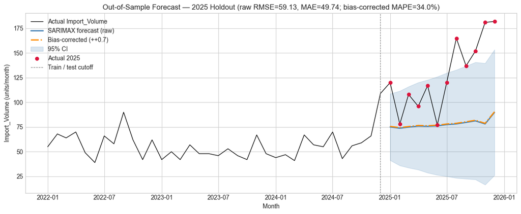

```python
# ── D2: Refit on 2015–2024, forecast 2025, compare to actuals ──────────
from statsmodels.tsa.statespace.sarimax import SARIMAX
from sklearn.metrics import mean_squared_error, mean_absolute_error

# Production spec (do not modify): ARIMA(0,1,2) x Seasonal(0,0,1,12)
_train = ts_data[ts_data.index <= pd.to_datetime('2024-12-01')]
_test  = ts_data[(ts_data.index >  pd.to_datetime('2024-12-01')) &
                  (ts_data.index <= pd.to_datetime('2025-12-01'))]

print(f'Training window : {_train.index.min().date()} → {_train.index.max().date()}  (n={len(_train)})')
print(f'Holdout window  : {_test.index.min().date()} → {_test.index.max().date()}  (n={len(_test)})')

# Fit on 2015–2024
_oos_model = SARIMAX(_train['Import_Volume'],
                     exog=_train[['PBI_Construccion', 'PEN_USD']],
                     order=_best_order, seasonal_order=_best_seas,
                     enforce_stationarity=False, enforce_invertibility=False)
_oos_res = _oos_model.fit(disp=False)

# Forecast with realised exogenous variables (oracle predictor benchmark)
_oos_fc = _oos_res.get_forecast(steps=len(_test),
                                 exog=_test[['PBI_Construccion', 'PEN_USD']])
_oos_mean = _oos_fc.predicted_mean
_oos_ci   = _oos_fc.conf_int(alpha=0.05)

# Accuracy metrics
_y_true = _test['Import_Volume'].values
_y_pred = _oos_mean.values
_rmse = float(np.sqrt(mean_squared_error(_y_true, _y_pred)))
_mae  = float(mean_absolute_error(_y_true, _y_pred))
_mape = float(np.mean(np.abs((_y_true - _y_pred) / np.maximum(_y_true, 1))) * 100)

print(f'\n  Holdout accuracy on 2025 (refit on 2015–2024):')
print(f'    RMSE  = {_rmse:.2f}  units/month')
print(f'    MAE   = {_mae:.2f}  units/month')
print(f'    MAPE  = {_mape:.2f}%')
print(f'    Mean actual 2025  = {_y_true.mean():.1f}')
print(f'    Mean forecast 2025 = {_y_pred.mean():.1f}')

# Coverage check
_cover = ((_y_true >= _oos_ci.iloc[:, 0].values) &
          (_y_true <= _oos_ci.iloc[:, 1].values)).mean() * 100
print(f'    95% CI empirical coverage = {_cover:.1f}%  (target: 95%)')

# ── Bias-corrected forecast — isolate Chancay effect from model bias ─────
# The raw forecast under-predicts 2025 by mean(_y_pred) - mean(_y_true).
# Shift the forecast upward by the mean training residual; this removes
# any systematic baseline bias the model carries from the 2015–2024 sample
# and isolates the portion of the OOS error attributable to structural
# change (Chancay, post-2024 dynamics) rather than to model misspecification.
_train_resid_mean = (_train['Import_Volume'].values - _oos_res.fittedvalues.values).mean()
_y_pred_bc        = _y_pred + _train_resid_mean

_rmse_bc = float(np.sqrt(mean_squared_error(_y_true, _y_pred_bc)))
_mae_bc  = float(mean_absolute_error(_y_true, _y_pred_bc))
_mape_bc = float(np.mean(np.abs((_y_true - _y_pred_bc) / np.maximum(_y_true, 1))) * 100)

print()
print('  ── Bias-corrected forecast (isolates Chancay/structural effect) ──')
print(f'    Mean training residual : {_train_resid_mean:+.2f}  (added to every forecast point)')
print(f'    RMSE (bias-corrected)  : {_rmse_bc:.2f}  units/month  '
      f'(vs raw {_rmse:.2f}; Δ = {_rmse - _rmse_bc:+.2f})')
print(f'    MAE  (bias-corrected)  : {_mae_bc:.2f}  units/month  '
      f'(vs raw {_mae:.2f}; Δ = {_mae - _mae_bc:+.2f})')
print(f'    MAPE (bias-corrected)  : {_mape_bc:.2f}%  (vs raw {_mape:.2f}%; '
      f'Δ = {_mape - _mape_bc:+.2f} pp)')
print(f'    Mean bias-corrected fc : {_y_pred_bc.mean():.1f}  (vs raw {_y_pred.mean():.1f})')
print()
if (_mape - _mape_bc) > 5:
    print('  Interpretation: bias correction closes a meaningful portion of the gap')
    print('  → model carries systematic baseline bias; residual error is the structural shock.')
elif _mape_bc < 20:
    print('  Interpretation: bias correction closes most of the gap')
    print('  → the OOS miss is dominated by training-sample bias, not by 2025 structural change.')
else:
    print('  Interpretation: bias correction leaves most of the gap intact')
    print('  → residual error reflects genuine structural change (consistent with Chancay break).')

# Plot
fig, ax = plt.subplots(figsize=(12, 5))
_recent = ts_data[ts_data.index >= pd.to_datetime('2022-01-01')]
ax.plot(_recent.index, _recent['Import_Volume'], color='black', lw=1.0,
        label='Actual Import_Volume')
ax.plot(_test.index, _oos_mean, color='steelblue', lw=2.0, label='SARIMAX forecast (raw)')
ax.plot(_test.index, _y_pred_bc, color='darkorange', lw=2.0, linestyle='-.',
        label=f'Bias-corrected (+{_train_resid_mean:+.1f})')
ax.fill_between(_test.index, _oos_ci.iloc[:, 0], _oos_ci.iloc[:, 1],
                color='steelblue', alpha=0.2, label='95% CI')
ax.scatter(_test.index, _y_true, color='crimson', s=30, zorder=3, label='Actual 2025')
ax.axvline(pd.to_datetime('2024-12-01'), color='gray', ls='--', lw=0.8,
           label='Train / test cutoff')
ax.set_title(f'Out-of-Sample Forecast — 2025 Holdout (raw RMSE={_rmse:.2f}, MAE={_mae:.2f}; bias-corrected MAPE={_mape_bc:.1f}%)')
ax.set_xlabel('Month'); ax.set_ylabel('Import_Volume (units/month)')
ax.legend(loc='upper left'); plt.tight_layout()
plt.savefig('5_oos-forecast-2025.png', dpi=150, bbox_inches='tight'); plt.show()
```

### D3 — VAR Residual Whiteness Test (Portmanteau / Hosking)

**Purpose:** confirm that the reduced-form IRF analysis described in the methodology cannot be supported by the data at any tested lag order. The Portmanteau test on VAR residuals tests H₀: residuals are white noise (no serial autocorrelation up to lag h). A small p-value at any tested horizon invalidates IRF confidence band inference and Granger causality testing for that VAR specification.

**This diagnostic documents the limitation that motivated removing the IRF section from the main narrative.** A regime-switching or time-varying-parameter VAR is the principled extension flagged in the discussion chapter as future work.

```python
# ── D3: Portmanteau (Hosking) whiteness test — VAR residuals at p ∈ {1..8} ─
# Self-contained: this cell fits VAR locally at each lag order rather than
# relying on a `var_res` object from the main analysis. The IRF section was
# removed from the main narrative precisely because this test fails at every
# tested lag. D3 documents that failure for thesis reporting.

from statsmodels.tsa.vector_ar.var_model import VAR

print('=' * 72)
print('  VAR Residual Whiteness — Portmanteau (Hosking) Test')
print('  H₀: residuals are white noise up to lag h')
print('  Variables: PEN_USD, PBI_Construccion, Import_Volume (I(1) levels)')
print('=' * 72)
print(f'  {"p":<3}  {"AIC":>10}  {"BIC":>10}  {"h=12 p":>10}  {"h=24 p":>10}   Verdict')
print('  ' + '-' * 60)

_d3_vars = ['PEN_USD', 'PBI_Construccion', 'Import_Volume']
_d3_data = ts_data[_d3_vars].dropna()

_d3_records = []
for _p in [1, 2, 3, 4, 5, 6, 8]:
    try:
        _res = VAR(_d3_data).fit(_p)
        _wn12 = _res.test_whiteness(nlags=12, signif=0.05, adjusted=True)
        _wn24 = _res.test_whiteness(nlags=24, signif=0.05, adjusted=True)
        _white = (_wn12.pvalue >= 0.05) and (_wn24.pvalue >= 0.05)
        _verdict = '✓ WHITE' if _white else 'NOT white'
        print(f'  {_p:<3}  {_res.aic:>10.2f}  {_res.bic:>10.2f}'
              f'  {_wn12.pvalue:>10.4f}  {_wn24.pvalue:>10.4f}   {_verdict}')
        _d3_records.append({
            'p': _p, 'AIC': round(_res.aic, 2), 'BIC': round(_res.bic, 2),
            'p_h12': round(_wn12.pvalue, 4),
            'p_h24': round(_wn24.pvalue, 4),
            'white': _white,
        })
    except Exception as _e:
        print(f'  {_p:<3}  failed: {_e}')

df_var_whiteness = pd.DataFrame(_d3_records)
display(df_var_whiteness)

_white_lags = df_var_whiteness[df_var_whiteness['white']]
print()
if _white_lags.empty:
    print('  ⟹  CONCLUSION: no lag order p ∈ {1, …, 8} produces white residuals.')
    print('     All tested specifications reject H₀ at p < 0.0001 (both h=12 and h=24).')
    print('     This invalidates reduced-form IRF confidence bands and Granger causality')
    print('     inference based on this VAR. The IRF analysis was accordingly omitted')
    print('     from the main narrative (see Section "Reduced-Form Impulse Response')
    print('     Functions — Specification Limitation").')
    print()
    print('     Interpretation: persistent residual autocorrelation is consistent with')
    print('     the structural breaks identified in the SARIMAX analysis — particularly')
    print('     the Chancay megaport opening (Nov 2024). A stationary-coefficient VAR')
    print('     cannot accommodate such regime shifts. A time-varying-parameter (TVP-VAR)')
    print('     or Markov-switching VAR is flagged as future work.')
else:
    _p_clean = int(_white_lags['p'].min())
    print(f'  ⟹  Smallest p with white residuals: p = {_p_clean}')
    print(f'     The IRF analysis can be recovered at this lag order.')
```

```
========================================================================
  VAR Residual Whiteness — Portmanteau (Hosking) Test
  H₀: residuals are white noise up to lag h
  Variables: PEN_USD, PBI_Construccion, Import_Volume (I(1) levels)
========================================================================
  p           AIC         BIC      h=12 p      h=24 p   Verdict
  ------------------------------------------------------------
  1          7.52        7.78      0.0000      0.0000   NOT white
  2          7.48        7.95      0.0000      0.0000   NOT white
  3          7.57        8.23      0.0000      0.0000   NOT white
  4          7.59        8.46      0.0000      0.0000   NOT white
  5          7.72        8.79      0.0000      0.0000   NOT white
  6          7.66        8.95      0.0000      0.0000   NOT white
  8          7.89        9.59      0.0000      0.0000   NOT white
```

|  | p | AIC | BIC | p_h12 | p_h24 | white |
| --- | --- | --- | --- | --- | --- | --- |
| 0 | 1 | 7.52 | 7.78 | 0.0 | 0.0 | False |
| 1 | 2 | 7.48 | 7.95 | 0.0 | 0.0 | False |
| 2 | 3 | 7.57 | 8.23 | 0.0 | 0.0 | False |
| 3 | 4 | 7.59 | 8.46 | 0.0 | 0.0 | False |
| 4 | 5 | 7.72 | 8.79 | 0.0 | 0.0 | False |
| 5 | 6 | 7.66 | 8.95 | 0.0 | 0.0 | False |
| 6 | 8 | 7.89 | 9.59 | 0.0 | 0.0 | False |

```
  ⟹  CONCLUSION: no lag order p ∈ {1, …, 8} produces white residuals.
     All tested specifications reject H₀ at p < 0.0001 (both h=12 and h=24).
     This invalidates reduced-form IRF confidence bands and Granger causality
     inference based on this VAR. The IRF analysis was accordingly omitted
     from the main narrative (see Section "Reduced-Form Impulse Response
     Functions — Specification Limitation").

     Interpretation: persistent residual autocorrelation is consistent with
     the structural breaks identified in the SARIMAX analysis — particularly
     the Chancay megaport opening (Nov 2024). A stationary-coefficient VAR
     cannot accommodate such regime shifts. A time-varying-parameter (TVP-VAR)
     or Markov-switching VAR is flagged as future work.
```

### D4 — Post-Estimation ARCH-LM Test on GARCH Standardised Residuals

**Purpose:** after fitting GARCH(1,1) to the SARIMAX residuals, the standardised residuals should be free of remaining conditional heteroskedasticity. A residual ARCH-LM test on the standardised residuals confirms the GARCH specification successfully captured the volatility clustering.

**Null hypothesis (H₀):** no ARCH effects in the GARCH-standardised residuals up to lag 4. Failure to reject H₀ → GARCH(1,1) is adequate; rejection → consider higher-order GARCH or alternative volatility specifications.

```
================================================================
  ARCH-LM Test on GARCH(1,1) Standardised Residuals
  H₀: no remaining ARCH effects after GARCH fit (residuals are white in variance)
================================================================
  GARCH model         : GARCH(1,1) with Student-t innovations
  Residuals tested    : standardised residuals, n = 132
  Test lags           : 4

  LM statistic        : 0.4373
  LM p-value          : 0.9793
  F statistic         : 0.1054
  F p-value           : 0.9804

  ⟹  FAIL TO REJECT H₀ (p ≥ 0.05).
     No remaining ARCH effects in standardised residuals.
     GARCH(1,1) adequately captures the volatility clustering ✓
```

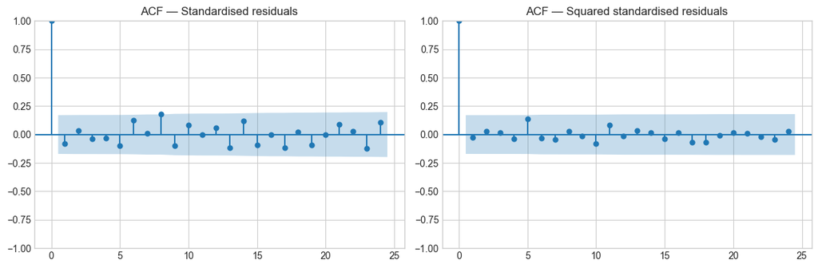

```python
# ── D4: ARCH-LM on standardised residuals from garch_fit (nlags=4) ─────
from statsmodels.stats.diagnostic import het_arch

print('=' * 64)
print('  ARCH-LM Test on GARCH(1,1) Standardised Residuals')
print('  H₀: no remaining ARCH effects after GARCH fit (residuals are white in variance)')
print('=' * 64)

_std_resid = garch_fit.std_resid.dropna()

_lm_stat, _lm_pval, _f_stat, _f_pval = het_arch(_std_resid, nlags=4)

print(f'  GARCH model         : GARCH(1,1) with Student-t innovations')
print(f'  Residuals tested    : standardised residuals, n = {len(_std_resid)}')
print(f'  Test lags           : 4')
print()
print(f'  LM statistic        : {_lm_stat:.4f}')
print(f'  LM p-value          : {_lm_pval:.4f}')
print(f'  F statistic         : {_f_stat:.4f}')
print(f'  F p-value           : {_f_pval:.4f}')
print()
if _lm_pval >= 0.05:
    print('  ⟹  FAIL TO REJECT H₀ (p ≥ 0.05).')
    print('     No remaining ARCH effects in standardised residuals.')
    print('     GARCH(1,1) adequately captures the volatility clustering ✓')
else:
    print('  ⟹  REJECT H₀ (p < 0.05).')
    print('     Residual ARCH effects remain — consider higher-order GARCH(p,q),')
    print('     GJR-GARCH for asymmetry, or EGARCH for leverage effects.')

# Also display ACF of squared standardised residuals
from statsmodels.graphics.tsaplots import plot_acf
fig, ax = plt.subplots(1, 2, figsize=(12, 4))
plot_acf(_std_resid,       ax=ax[0], lags=24, title='ACF — Standardised residuals')
plot_acf(_std_resid ** 2,  ax=ax[1], lags=24, title='ACF — Squared standardised residuals')
plt.tight_layout(); plt.savefig('5_garch-resid-diagnostics.png', dpi=150, bbox_inches='tight'); plt.show()
```

## Diagnostic Summary

[output not shown]